# 1430_hands-on-part-1_EN

```python
# @title ⚙️ T2 · Diagnosis and structured extraction { display-mode: "form" }
from dataclasses import dataclass, field

def diagnose(doc):
    rows = []
    for page in doc:
        chars = len(page.get_text().strip())
        images = len(page.get_images(full=True))
        status = "text" if chars >= 50 else ("scanned" if images else "empty")
        rows.append({"Page": page.number + 1, "Characters": chars, "Images": images, "Status": status})
    return pd.DataFrame(rows)

@dataclass
class Element:
    type: str           # "heading", "paragraph", "table" or "ocr"
    text: str
    page: int
    box: tuple          # rectangle (x0, y0, x1, y1) on the page
    level: int = 0      # heading level (1 = most important)
    section: str = ""   # nearest heading
    path: str = ""      # full heading breadcrumb, e.g. "2. Strategy › 2.4 Focus Areas"

FOOTNOTE_MARKER = re.compile(r"(?<=[a-z\)\u201d\"])\.(\d{1,3})(?=\s+[A-Z\u201c\"])")

def _nfkc(t):
    return unicodedata.normalize("NFKC", t)

def page_lines(page):
    lines = []
    for block in page.get_text("dict")["blocks"]:
        if block.get("type") != 0:
            continue
        for line in block["lines"]:
            spans = [s for s in line["spans"] if s["text"].strip()]
            if not spans:
                continue
            lines.append({"text": _nfkc("".join(s["text"] for s in line["spans"])).strip(),
                          "size": round(max(s["size"] for s in spans), 1),
                          "bold": any((s["flags"] & 16) or "Bold" in s.get("font", "") for s in spans),
                          "box": pymupdf.Rect(line["bbox"]), "block": block["number"]})
    return lines

def _signature(text):
    return re.sub(r"\d+", "#", text.lower()).strip()

def _tables(page):
    if not EXTRACT_TABLES:
        return []
    with contextlib.redirect_stdout(io.StringIO()):
        found = page.find_tables().tables
    result = []
    for t in found:
        rows = [[_nfkc((c or "").replace("\n", " ")).strip() for c in r] for r in t.extract()]
        headers = [_nfkc((c or "").replace("\n", " ")).strip() for c in t.header.names]
        if rows and rows[0] == headers:
            rows = rows[1:]
        if rows and len(headers) >= 2:
            result.append({"box": pymupdf.Rect(t.bbox), "headers": headers, "rows": rows})
    return result

def linearise(table, caption):
    sentences = []
    for row in table["rows"]:
        if not any(row):
            continue
        values = "; ".join(f"{table['headers'][j]}: {row[j]}" for j in range(1, len(row))
                           if j < len(table["headers"]) and row[j])
        sentences.append(f"{row[0]} — {values}.")
    return (f"{caption}\n" if caption else "") + "\n".join(sentences)

def ocr_page(page):
    ensure_package("pytesseract", "pytesseract")
    if not shutil.which("tesseract") and shutil.which("apt-get") and ENV["name"] in ("colab", "kaggle"):
        print("Installing Tesseract (about a minute)…")
        subprocess.run("apt-get install -y -qq tesseract-ocr tesseract-ocr-fra > /dev/null 2>&1 || "
                       "(apt-get update -qq > /dev/null 2>&1 && apt-get install -y -qq tesseract-ocr tesseract-ocr-fra > /dev/null 2>&1)",
                       shell=True)
    import pytesseract
    from PIL import Image
    installed = set(pytesseract.get_languages(config=""))
    language = "+".join(l for l in OCR_LANGUAGE.split("+") if l in installed) or "eng"
    if language != OCR_LANGUAGE:
        print(f"⚠️ OCR language “{OCR_LANGUAGE}” unavailable: using “{language}”.")
    pix = page.get_pixmap(dpi=300)
    image = Image.frombytes("RGB", (pix.width, pix.height), pix.samples)
    text = _nfkc(pytesseract.image_to_string(image, lang=language))
    return [re.sub(r"\s*\n\s*", " ", p).strip() for p in re.split(r"\n\s*\n", text) if len(p.strip()) > 3]

CAPTION = re.compile(r"^(Table|Figure|Chart|Graph|Tableau|Graphique)\b")
LEADER_LINE = re.compile(r"\.{4,}\s*\d{1,4}\s*$|\u2026{2,}")      # "Chapter 3 ......... 42"
PAGE_NUMBER_ONLY = re.compile(r"^(page\s*)?[ivxlcdm\d]{1,6}$", re.I)
NUMBERED_HEADING = re.compile(r"^\d{1,2}(\.\d{1,2}){0,3}[.)]?\s+\S")

def extract_structure(doc):
    last = doc.page_count if not MAX_PAGES_PER_DOCUMENT else min(doc.page_count, MAX_PAGES_PER_DOCUMENT)
    pages = {p.number + 1: page_lines(p) for p in doc if p.number < last}
    with_text = [n for n, l in pages.items() if l]
    # 1. repeated running headers and footers
    repeated = set()
    if REMOVE_HEADERS and len(with_text) >= 2:
        counts = Counter()
        for n in with_text:
            height = doc[n - 1].rect.height
            counts.update({_signature(l["text"]) for l in pages[n]
                           if l["box"].y1 < height * 0.1 or l["box"].y0 > height * 0.9})
        repeated = {s for s, c in counts.items() if c >= max(2, 0.5 * len(with_text))}
    # 2. body text size and heading sizes
    weights = Counter()
    for l in (l for n in with_text for l in pages[n]):
        weights[l["size"]] += len(l["text"])
    body = weights.most_common(1)[0][0] if weights else 10
    heading_sizes = sorted({l["size"] for n in with_text for l in pages[n]
                            if l["size"] >= body * 1.2 and len(l["text"]) <= 120}, reverse=True)
    level_of = {s: i + 1 for i, s in enumerate(heading_sizes)}
    def is_running_line(line, page):
        if _signature(line["text"]) in repeated:
            return True
        # single-page documents: nothing repeats, so use position and font size instead
        height = page.rect.height
        in_margin = line["box"].y1 < height * 0.08 or line["box"].y0 > height * 0.92
        return REMOVE_HEADERS and len(with_text) < 2 and in_margin and line["size"] < body * 0.85 and len(line["text"]) < 90
    elements, removed, dropped_toc = [], 0, 0
    for n in sorted(pages):
        page = doc[n - 1]
        if not pages[n]:
            if USE_OCR and page.get_images():
                for paragraph in ocr_page(page):
                    elements.append(Element("ocr", paragraph, n, tuple(page.rect)))
            continue
        tables = _tables(page)
        pieces, current = [], None                     # pieces: (y, element, block[, table])
        for l in pages[n]:
            if is_running_line(l, page) or PAGE_NUMBER_ONLY.match(l["text"]):
                removed += 1
                continue
            if DROP_TABLE_OF_CONTENTS and LEADER_LINE.search(l["text"]):
                dropped_toc += 1                      # table of contents, list of figures…
                continue
            if any(l["box"].intersects(t["box"]) for t in tables):
                continue
            numbered = (NUMBERED_HEADING.match(l["text"]) and len(l["text"]) <= 90
                        and l["size"] >= body * 0.98 and l["bold"])
            if l["size"] in level_of or numbered:
                if current: pieces.append(current); current = None
                if pieces and pieces[-1][1].type == "heading" and pieces[-1][2] == l["block"]:
                    heading = pieces[-1][1]
                    heading.text += " " + l["text"]
                    heading.box = tuple(pymupdf.Rect(heading.box) | l["box"])
                else:
                    pieces.append((l["box"].y0, Element("heading", l["text"], n, tuple(l["box"]),
                                                        level_of.get(l["size"], len(heading_sizes) + 1)), l["block"]))
                continue
            if current and current[2] == l["block"]:
                el = current[1]
                if el.text.endswith("-") and l["text"][:1].islower():
                    el.text = el.text[:-1] + l["text"]          # re-join hyphenated words
                else:
                    el.text += " " + l["text"]
                el.box = tuple(pymupdf.Rect(el.box) | l["box"])
            else:
                if current: pieces.append(current)
                current = (l["box"].y0, Element("paragraph", l["text"], n, tuple(l["box"])), l["block"])
        if current: pieces.append(current)
        for t in tables:
            pieces.append((t["box"].y0, Element("table", "", n, tuple(t["box"])), None, t))
        pieces.sort(key=lambda p: p[0])
        for p in pieces:
            el = p[1]
            if el.type == "table":
                previous = elements[-1] if elements else None
                table = p[3]
                if (previous is not None and previous.type == "table" and previous.page == n - 1
                        and len(previous.table["headers"]) == len(table["headers"])):
                    # continuation of the previous page's table: its "header" row is really a data row
                    previous.table["rows"] += [table["headers"]] + table["rows"]
                    previous.text = linearise(previous.table, previous.caption)
                    previous.extra.append((n, tuple(table["box"])))
                    continue
                caption = ""
                if previous and previous.type == "paragraph" and CAPTION.match(previous.text):
                    caption = previous.text
                    elements.pop()
                el.text = linearise(table, caption)
                el.table, el.caption, el.extra = table, caption, []
            elements.append(el)
    # 3. attach every element to its section and to its full heading path
    section, stack = "", {}
    for i, el in enumerate(elements):
        if el.type == "heading":
            document_title = i == 0 and el.level == 1 and len(heading_sizes) > 1
            section = "" if document_title else el.text
            if not document_title:
                stack = {lvl: t for lvl, t in stack.items() if lvl < el.level}
                stack[el.level] = el.text
        else:
            el.text = FOOTNOTE_MARKER.sub(". ", el.text)      # "…is high.5 The AI industry" → "…is high. The AI industry"
        el.section = section if el.type != "ocr" else f"Page {el.page} (OCR text)"
        el.path = " › ".join(stack[lvl] for lvl in sorted(stack)) or el.section
    return elements, {"headers removed": removed, "contents lines dropped": dropped_toc,
                      "body size": body, "heading sizes": heading_sizes, "pages read": len(pages)}
print("✅ T2 ready.")
```

```
✅ T2 ready.
```

```python
# @title ⚙️ T3 · Splitting into passages { display-mode: "form" }
@dataclass
class Passage:
    id: int
    doc_id: int
    doc: str             # short document title
    section: str
    text: str
    index_text: str      # text used for search (with a contextual header)
    boxes: list          # [(page, rectangle), …]
    kind: str = "text"

    @property
    def pages(self):
        return sorted({p for p, _ in self.boxes})

    path: str = ""       # heading breadcrumb of the passage
    parent_id: int = -1  # context passage this search window belongs to

    @property
    def pages_label(self):
        pages = self.pages
        return f"p. {pages[0]}" if len(pages) == 1 else f"pp. {pages[0]}–{pages[-1]}"

    @property
    def citation(self):
        return f"{self.doc} · {self.section or 'start of document'} · {self.pages_label}"

def _sentences(text):
    return [s.strip() for s in re.split(r"(?<=[.!?;])\s+(?=[A-ZÀ-Ý0-9«•–-])", text) if s.strip()]

def split_passages(document, start=0, max_chars=1000, overlap=2, min_chars=280):
    passages = []
    def add(section, units, kind="text"):
        text = ("\n" if kind == "table" else " ").join(u[0] for u in units)
        boxes = list(dict.fromkeys((u[1], u[2]) for u in units))
        if len(text.strip()) < 40 or text.strip().lower() in seen:
            return                                   # scraps and duplicates add noise, never answers
        seen.add(text.strip().lower())
        breadcrumb = path or section
        # a short passage is glued to the previous one rather than left alone without context
        if (passages and len(text) < min_chars and passages[-1].kind == kind == "text"
                and passages[-1].section == section and len(passages[-1].text) + len(text) <= max_chars * 1.4):
            previous = passages[-1]
            previous.text += " " + text
            previous.index_text += " " + text
            previous.boxes += [b for b in boxes if b not in previous.boxes]
            return
        header = f"{document.title} — {breadcrumb}" if breadcrumb else document.title
        passages.append(Passage(start + len(passages), document.id, document.short, section, text,
                                f"{header}. {text}", boxes, kind, breadcrumb))
    seen = set()
    buffer, section, path = [], None, ""
    def flush():
        nonlocal buffer
        i = 0
        while i < len(buffer):
            batch, length, j = [], 0, i
            while j < len(buffer) and (not batch or length + len(buffer[j][0]) <= max_chars):
                batch.append(buffer[j]); length += len(buffer[j][0]) + 1; j += 1
            add(section, batch)
            if j >= len(buffer):
                break
            i = max(j - overlap, i + 1)
        buffer = []
    for el in document.elements:
        if el.type == "heading":
            continue
        if el.section != section:
            flush()
            section, path = el.section, el.path
        if el.type == "table":
            flush()
            lines = el.text.split("\n")
            batch = []
            for line in lines:
                if batch and sum(len(x) for x in batch) + len(line) > max_chars:
                    add(section, [(x, el.page, el.box) for x in ([lines[0]] if batch[0] != lines[0] else []) + batch], "table")
                    batch = []
                batch.append(line)
            if batch:
                add(section, [(x, el.page, el.box) for x in ([lines[0]] if batch[0] != lines[0] else []) + batch], "table")
            for p in passages:
                if p.kind == "table" and p.boxes and p.boxes[0] == (el.page, el.box):
                    p.boxes += [b for b in getattr(el, "extra", []) if b not in p.boxes]
            continue
        buffer += [(s, el.page, el.box) for s in _sentences(el.text)]
    flush()
    return passages
# ── The five levels of chunking, from the naive baseline to the one that measures best ──
CHUNKING_LEVELS = {
    "fixed":     ("1 · Fixed blocks",
                  "Cuts every MAX_CHARS characters, ignoring sentences, sections and tables."),
    "sentences": ("2 · Sentence windows",
                  "Whole sentences, N at a time, sliding. Nothing is cut mid-sentence, but a passage "
                  "no longer knows which section it comes from."),
    "sections":  ("3 · Structural passages",
                  "Follows the headings found by the extractor; each table is a passage of its own and "
                  "the heading path travels with the text."),
    "hybrid":    ("4 · Two granularities",
                  "Indexes the structural passages AND small sentence windows: the search becomes precise "
                  "while the reader still receives a whole passage."),
    "smart":     ("5 · Two granularities, tables and context",
                  "Adds each table row as its own unit and sends the neighbouring passages of the section "
                  "along with the answer."),
}

def _document_pieces(document):
    """Every text fragment of the document, in reading order, with its page and box."""
    return [(el.text, el.page, el.box) for el in document.elements if el.text.strip()]

def make_passages(document, start=0):
    """Levels 1 and 2 ignore the structure of the report; levels 3 to 5 use it."""
    if CHUNK_STRATEGY not in ("fixed", "sentences"):
        return split_passages(document, start, MAX_CHARS, OVERLAP_SENTENCES, MIN_CHARS)
    passages, pieces = [], _document_pieces(document)
    def add(text, boxes):
        text = " ".join(text.split())
        if len(text) < 40:
            return
        passages.append(Passage(start + len(passages), document.id, document.short, "", text,
                                f"{document.title}. {text}", list(dict.fromkeys(boxes)), "text", ""))
    if CHUNK_STRATEGY == "fixed":
        overlap, buffer, boxes = int(MAX_CHARS * 0.12), "", []
        for text, page, box in pieces:
            boxes.append((page, box))
            for word in text.split():
                if len(buffer) + len(word) + 1 > MAX_CHARS:     # cut in the middle of a sentence
                    add(buffer, boxes)
                    buffer, boxes = buffer[-overlap:], boxes[-2:]
                buffer += " " + word
        add(buffer, boxes)
    else:                                                        # "sentences"
        units = [(s, page, box) for text, page, box in pieces for s in (_sentences(text) or [text])]
        for i in range(0, max(1, len(units) - WINDOW_SENTENCES + 1), WINDOW_STRIDE):
            window = units[i:i + WINDOW_SENTENCES]
            add(" ".join(u[0] for u in window), [(u[1], u[2]) for u in window])
    return passages

def build_search_units(passages, strategy=None, size=None, stride=None):
    """Levels 4 and 5 index a second, finer granularity: small windows — and, at level 5, table
    rows — which point back through `parent_id` to the passage a reader should actually be given."""
    strategy = strategy or CHUNK_STRATEGY
    size, stride = size or WINDOW_SENTENCES, stride or WINDOW_STRIDE
    for p in passages:
        p.parent_id = p.id
    if strategy not in ("hybrid", "smart"):
        return list(passages)
    units, next_id = list(passages), max((p.id for p in passages), default=-1) + 1
    for p in passages:
        if p.kind == "table":
            if strategy != "smart":
                continue
            lines = p.text.split("\n")
            caption = lines[0] if lines and " — " not in lines[0] else ""
            for line in (lines[1:] if caption else lines):
                if len(line) < 15:
                    continue
                text = f"{caption} {line}".strip()                 # one row, with its caption
                units.append(Passage(next_id, p.doc_id, p.doc, p.section, text,
                                     f"{p.path or p.section}. {text}", p.boxes, "table", p.path, p.id))
                next_id += 1
            continue
        sentences = _sentences(p.text) or [p.text]
        for i in range(0, max(1, len(sentences) - size + 1), stride):
            text = " ".join(sentences[i:i + size])
            if len(text) < 60:
                continue
            units.append(Passage(next_id, p.doc_id, p.doc, p.section, text,
                                 f"{p.path or p.section}. {text}", p.boxes, p.kind, p.path, p.id))
            next_id += 1
    return units

print(f"✅ T3 ready · chunking level {CHUNKING_LEVELS[CHUNK_STRATEGY][0]}.")
```

```
✅ T3 ready · chunking level 5 · Two granularities, tables and context.
```

```python
# @title ⚙️ T4 · Search { display-mode: "form" }
from sklearn.feature_extraction.text import TfidfVectorizer
from sklearn.decomposition import TruncatedSVD
from sklearn.preprocessing import Normalizer

LANG = DOCUMENT_LANGUAGE if DOCUMENT_LANGUAGE in ("en", "fr") else "en"

# --- Language resources (stop words for both languages are always ignored) ---------------------
STOPWORDS = set("""a an the and or of in on at to for from by with is are was were be been being what which who
whom whose when where why how does do did can could will would shall should may might it its this that these those
there their they them his her he she we you i as than then so such not no nor about into over under also any all
each per much many get give tell me please document documents report reports say says said information show between stand stands standing acronym abbreviation abbreviations initials mean means called number numbers proposed propose proposes presented described mentioned according
le la les l un une des de du d et en au aux est sont ete ce cet cette ces qui que quoi quel quelle quels quelles
comment combien quand ou il elle se sa son ses leur leurs ne pas plus par pour sur dans avec y t n s qu etait
sera peut peuvent fait faire lors entre apres avant tout toute tous toutes ainsi dont tres rapport dit indique selon
informations donne donnent parle concernant sujet ils elles eux lui chez aussi meme""".split())

SUFFIXES = {
    "en": sorted(["ational", "ations", "ation", "ments", "ment", "ness", "ings", "ing", "ities", "ity", "ies",
                  "ied", "ers", "er", "ed", "es", "ly", "al", "s", "e"], key=len, reverse=True),
    "fr": sorted(["ements", "ement", "ations", "ation", "itions", "ition", "ances", "ance", "ences", "ence",
                  "euses", "euse", "eurs", "eur", "ites", "ite", "iques", "ique", "ives", "ive", "ifs", "if",
                  "elles", "elle", "iels", "iel", "aux", "ants", "ant", "ents", "ent", "ees", "ee", "es", "er",
                  "age", "s", "e", "x"], key=len, reverse=True),
}

GLOSSARIES = {
    "en": {
        # users' words                   -> words used in publications
        "inhabitants": "population resident people", "residents": "population resident",
        "how many people": "population", "people live": "population",
        "jobless": "unemployment unemployed", "out of work": "unemployment unemployed",
        "young people": "youth 15 24", "youth": "young 15 24",
        "woman": "women", "man": "men", "female": "women", "male": "men",
        "city": "urban", "cities": "urban", "towns": "urban", "countryside": "rural", "villages": "rural",
        "proportion": "share rate", "percentage": "share rate",
        "microdata": "anonymised files", "individual data": "microdata anonymised",
        "get access": "available access", "obtain": "available access",
        "released": "release published", "come out": "released published", "published": "released",
        "when": "published released date", "publication": "published released",
        "did not respond": "non-response reweighting", "non-response": "reweighting",
        "first quarter": "q1", "second quarter": "q2", "third quarter": "q3", "fourth quarter": "q4",
        "change": "down up", "changed": "down up", "evolve": "down up", "trend": "down up",
        "informal": "social protection contract", "wage": "income", "salary": "income", "earnings": "income",
        "sample": "dwellings drawn areas", "definition": "glossary", "what is meant by": "glossary",
        "next census": "census scheduled", "household size": "average size household",
    },
    "fr": {
        "habitants": "population residente personnes", "gens": "population personnes",
        "vivent": "population residente", "combien de personnes": "population",
        "ville": "urbain", "villes": "urbain", "campagne": "rural",
        "sans emploi": "chomage chomeur", "chomeurs": "chomage", "travail": "emploi",
        "jeunes": "15 24 ans", "proportion": "taux part", "pourcentage": "taux part",
        "microdonnees": "fichiers donnees individuelles anonymises",
        "chercheur": "chercheurs", "obtenir": "acceder accessibles acces",
        "sort": "publie publies diffusion paraitra", "sortent": "publie publies diffusion paraitra",
        "sortira": "paraitra publie", "publication": "publies paraitra", "quand": "date publies paraitra",
        "pas repondu": "non reponse repondération", "non-reponse": "repondération",
        "premier trimestre": "t1", "deuxieme trimestre": "t2", "second trimestre": "t2",
        "troisieme trimestre": "t3", "quatrieme trimestre": "t4",
        "evolue": "hausse baisse", "evolution": "hausse baisse", "varie": "hausse baisse",
        "informel": "informelle protection sociale contrat", "salaire": "revenu",
        "echantillon": "logements tirage zones", "definition": "glossaire", "signifie": "glossaire",
        "prochain recensement": "recensement programme", "taille des menages": "taille moyenne menage",
    },
}
GLOSSARY = GLOSSARIES[LANG]          # 🧪 add your own entries: GLOSSARY["jobless rate"] = "unemployment rate"

def strip_accents(text):
    return "".join(c for c in unicodedata.normalize("NFD", text) if unicodedata.category(c) != "Mn")

def stem(word):
    if any(ch.isdigit() for ch in word):
        return word
    for _ in range(2 if LANG == "en" else 1):
        for suffix in SUFFIXES[LANG]:
            if word.endswith(suffix) and len(word) - len(suffix) >= 4:
                word = word[: -len(suffix)]
                break
    return word

def analyse(text):
    t = strip_accents(text.lower())
    if LANG == "en":
        t = re.sub(r"(?<=\d),(?=\d{3}\b)", "", t)                    # 18,452,300 -> 18452300
        tokens = re.findall(r"[a-z0-9]+(?:\.\d+)?", t)
    else:
        t = re.sub(r"(?<=\d)[\s\u00a0\u202f](?=\d{3}\b)", "", t)      # 18 452 300 -> 18452300
        tokens = re.findall(r"[a-z0-9]+(?:,\d+)?", t)
    return [stem(w) for w in tokens if w not in STOPWORDS and len(w) > 1]
```

```python
# --- Spelling tolerance ------------------------------------------------------------------------
# Users mistype, especially in a second language: "coutries", "assessement", "developement".
# A word the documents never contain is otherwise treated as "unknown, therefore decisive",
# which sinks the whole question. These helpers map it to the nearest word the documents DO use.
import difflib

VOCABULARY_FORMS = {}      # stem -> the form as actually written in the documents
TRIGRAM_INDEX = {}         # character trigram -> stems containing it (fast candidate lookup)

def _trigrams(word):
    padded = f"  {word} "
    return {padded[i:i + 3] for i in range(len(padded) - 2)}

def build_vocabulary(passages):
    """Collect the surface forms of the documents and index them by character trigram."""
    forms = {}
    for p in passages:
        for word in re.findall(r"[^\W\d_]{3,}", strip_accents(p.text.lower())):
            if word not in STOPWORDS:
                forms.setdefault(stem(word), Counter())[word] += 1
    VOCABULARY_FORMS.clear()
    VOCABULARY_FORMS.update({root: c.most_common(1)[0][0] for root, c in forms.items()})
    TRIGRAM_INDEX.clear()
    for root in VOCABULARY_FORMS:
        for gram in _trigrams(root):
            TRIGRAM_INDEX.setdefault(gram, set()).add(root)

def closest_term(root, minimum=0.86):
    """Nearest document term for a word the collection does not contain, or None.
    The threshold is deliberately strict: a genuinely foreign word ("maize", "hospital")
    must stay unknown, because that is what makes an out-of-scope question refusable."""
    if len(root) < 4 or root in VOCABULARY_FORMS:
        return None
    candidates = Counter()
    for gram in _trigrams(root):
        for other in TRIGRAM_INDEX.get(gram, ()):
            candidates[other] += 1
    best, best_score = None, minimum
    for other, _ in candidates.most_common(40):
        if abs(len(other) - len(root)) > 2:
            continue
        score = difflib.SequenceMatcher(None, root, other).ratio()
        if score > best_score:
            best, best_score = other, score
    return best

def fix_spelling(question):
    """Replace each mistyped word by the closest word the documents really use.
    Returns the corrected question and the list of corrections, which is always displayed."""
    corrections = []
    def replace(match):
        word = match.group(0)
        plain = strip_accents(word.lower())
        if plain in STOPWORDS or stem(plain) in VOCABULARY_FORMS:
            return word
        near = closest_term(stem(plain))
        if not near:
            return word
        corrections.append((word, VOCABULARY_FORMS[near]))
        return VOCABULARY_FORMS[near]
    return (re.sub(r"[^\W\d_]{4,}", replace, question) if VOCABULARY_FORMS else question), corrections

ACRONYMS = {}          # filled from the documents themselves: "DIL" -> "Data Innovation Lab"
_ACRONYM_IN_TEXT = re.compile(r"([A-Z][\w’'\-]*(?:\s+[a-z\w’'\-]+){1,5}(?:\s+[A-Z][\w’'\-]*)?)\s*\(([A-Z]{2,6})s?\)")
_ACRONYM_IN_LIST = re.compile(r"(?:^|\n|;|—|\|)\s*([A-Z]{2,6})\s*(?:[—:\-–]|\s{2,})\s*([A-Z][^.;\n|]{4,60})")

def build_acronyms(passages):
    """Institutional reports are full of acronyms: learn them from the documents."""
    found = {}
    for p in passages:
        for expansion, acronym in _ACRONYM_IN_TEXT.findall(p.text):
            found.setdefault(acronym, Counter())[expansion.strip()] += 1
        for acronym, expansion in _ACRONYM_IN_LIST.findall(p.text):
            found.setdefault(acronym, Counter())[expansion.strip()] += 1
    return {a: counts.most_common(1)[0][0] for a, counts in found.items()
            if counts.most_common(1)[0][1] >= 1 and len(counts.most_common(1)[0][0].split()) >= 2}

def expand_query(question):
    q = " " + re.sub(r"[^a-z0-9-]+", " ", strip_accents(question.lower())) + " "
    added = [(key, terms) for key, terms in GLOSSARY.items() if f" {key} " in q]
    for acronym, expansion in ACRONYMS.items():
        if f" {acronym.lower()} " in q:
            added.append((acronym, expansion))
    return question + " " + " ".join(t for _, t in added), added

def concepts(question):
    """Each term of the question, with the synonyms the glossary attaches to it."""
    _, added = expand_query(question)
    synonyms = {}
    for key, terms in added:
        for word in analyse(key) or [stem(strip_accents(key.split()[-1]))]:
            synonyms.setdefault(word, set()).update(analyse(terms))
    return [(t, {t} | synonyms.get(t, set())) for t in dict.fromkeys(analyse(question))]

class BM25Index:
    """BM25 over a sparse term-document matrix: stays fast on thousands of passages."""

    def __init__(self, passages, k1=1.5, b=0.75):
        from scipy.sparse import csr_matrix
        self.passages, self.k1, self.b = passages, k1, b
        self.docs = [analyse(p.index_text) for p in passages]
        n = len(self.docs)
        self.vocabulary, rows, cols, values = {}, [], [], []
        for i, d in enumerate(self.docs):
            for term, f in Counter(d).items():
                j = self.vocabulary.setdefault(term, len(self.vocabulary))
                rows.append(i); cols.append(j); values.append(f)
        self.matrix = csr_matrix((values, (rows, cols)), shape=(n, max(1, len(self.vocabulary))), dtype=np.float32)
        lengths = np.array([len(d) for d in self.docs], dtype=np.float32)
        self.avg_len = max(1e-9, float(lengths.mean()) if n else 1.0)
        self.norm = (self.k1 * (1 - self.b + self.b * lengths / self.avg_len)).astype(np.float32)
        df = np.asarray((self.matrix > 0).sum(axis=0)).ravel()
        idf = np.log(1 + (n - df + 0.5) / (df + 0.5))
        self.idf_vector = idf.astype(np.float32)
        self.idf = {t: float(idf[j]) for t, j in self.vocabulary.items()}
        self.idf_max = max(self.idf.values()) if self.idf else 1.0

    def search(self, question, k=30):
        terms = [t for t in analyse(expand_query(question)[0]) if t in self.vocabulary]
        if not terms:
            return []
        columns = [self.vocabulary[t] for t in dict.fromkeys(terms)]
        frequencies = self.matrix[:, columns].toarray()
        weights = self.idf_vector[columns] * (self.k1 + 1)
        scores = (weights * frequencies / (frequencies + self.norm[:, None])).sum(axis=1)
        order = [i for i in np.argsort(-scores)[:k] if scores[i] > 0]
        return [(self.passages[i], float(scores[i])) for i in order]
```

```python
import hashlib
_EMBEDDING_CACHE = {}
class SemanticIndex:
    def __init__(self, passages):
        self.passages, self.mode, self.error = passages, None, None
        texts = [p.index_text for p in passages]
        if USE_EMBEDDINGS:
            try:
                if INSTALL_EMBEDDINGS:
                    ensure_package("sentence_transformers", "sentence-transformers")
                from sentence_transformers import SentenceTransformer
                if EMBEDDING_MODEL not in _EMBEDDING_CACHE:
                    _EMBEDDING_CACHE[EMBEDDING_MODEL] = SentenceTransformer(EMBEDDING_MODEL)
                self.model = _EMBEDDING_CACHE[EMBEDDING_MODEL]
                key = hashlib.sha1((EMBEDDING_MODEL + "|" + "|".join(texts)).encode("utf-8")).hexdigest()[:16]
                cached = CACHE_DIR / f"embeddings_{key}.npy"
                if USE_CACHE and cached.exists():
                    self.matrix = np.load(cached)
                else:
                    self.matrix = self.model.encode(texts, normalize_embeddings=True, batch_size=32,
                                                    show_progress_bar=len(texts) > 200)
                    if USE_CACHE:
                        np.save(cached, self.matrix)
                self.mode, self.name = "embeddings", f"Embeddings · {EMBEDDING_MODEL.split('/')[-1]}"
            except Exception as error:
                self.error = type(error).__name__
        if self.mode is None:                      # offline fallback: latent semantic analysis
            self.vectorizer = TfidfVectorizer(analyzer="char_wb", ngram_range=(3, 5),
                                              strip_accents="unicode", sublinear_tf=True)
            m = self.vectorizer.fit_transform(texts)
            self.svd = TruncatedSVD(n_components=max(1, min(96, m.shape[0] - 1, m.shape[1] - 1)), random_state=0)
            self.normalizer = Normalizer()
            self.matrix = self.normalizer.fit_transform(self.svd.fit_transform(m))
            self.mode, self.name = "lsa", "Approximate semantic search · offline LSA"

    def _encode(self, text):
        if self.mode == "embeddings":
            return self.model.encode([text], normalize_embeddings=True)
        return self.normalizer.transform(self.svd.transform(self.vectorizer.transform([text])))

    def search(self, question, k=30):
        scores = (self.matrix @ self._encode(expand_query(question)[0]).T).ravel()
        order = np.argsort(-scores)[:k]
        return [(self.passages[i], float(scores[i])) for i in order]

def rrf_fusion(rankings, k=60, top=12):
    scores, objects = {}, {}
    for ranking in rankings:
        for rank, (p, _) in enumerate(ranking, start=1):
            scores[p.id] = scores.get(p.id, 0.0) + 1.0 / (k + rank)
            objects[p.id] = p
    order = sorted(scores, key=scores.get, reverse=True)[:top]
    return [(objects[i], scores[i]) for i in order]

# ── What kind of answer the question is asking for (used by the reranker and the extractor) ──
QUESTION_TYPES = {
    "count": re.compile(r"\b(how many|how much|number of|combien|nombre de)\b", re.I),
    "date": re.compile(r"\b(when|what date|which year|quand|en quelle annee)\b", re.I),
    "list": re.compile(r"\b(list|name the|which \w+ (are|were|have|took)|what are the|quels|quelles)\b", re.I),
    "definition": re.compile(r"\b(what is an?|what are an?|define|definition of|stands? for|what does \w+ mean|"
                             r"signifie|qu'est-ce)\b", re.I),
}   # order matters: the first pattern that matches wins
NUMBER_IN_TEXT = re.compile(r"\b\d[\d.,]*\b|\b(one|two|three|four|five|six|seven|eight|nine|ten|eleven|twelve|"
                            r"deux|trois|quatre|cinq|six|sept|huit|neuf|dix|onze|douze)\b", re.I)
CROSS_REFERENCE = re.compile(r"\b(figure|table|tableau|graph|chart|annex|annexe|section|page|p\.)\s*\d+", re.I)
ENUMERATION = re.compile(r"(?:,|;|\band\b|\bet\b)[^,;]{2,70}(?:,|;|\band\b|\bet\b)", re.I | re.S)
A_YEAR = re.compile(r"\b(19|20)\d{2}\b")

def question_type(question):
    for name, pattern in QUESTION_TYPES.items():
        if pattern.search(question):
            return name
    return "other"

def carries_a_number(sentence):
    """A real quantity, not a cross-reference such as "Figure 8" or "see Table 3"."""
    return bool(NUMBER_IN_TEXT.search(CROSS_REFERENCE.sub(" ", sentence)))

# ── The four levels of reranking ──
RERANKING_LEVELS = {
    "none":          ("0 · None", "Keeps the order produced by the fusion of the two searches."),
    "coverage":      ("1 · Question coverage", "Share of the question's weighted terms present in the passage."),
    "smart":         ("2 · Coverage, density and answer type",
                      "Equal coverage is broken by the answer type (a “how many” question prefers a passage "
                      "carrying a quantity, a “list” question one carrying an enumeration), then by term density."),
    "cross-encoder": ("3 · Neural cross-encoder",
                      "A model reads the question and the passage together and scores the pair. The most "
                      "accurate, and the slowest: it needs sentence-transformers."),
}

class Reranker:
    def __init__(self, bm25, mode=None):
        self.bm25 = bm25
        self.mode = mode or RERANKING
        self.cross = None
        if self.mode == "cross-encoder":
            try:
                ensure_package("sentence_transformers", "sentence-transformers")
                from sentence_transformers import CrossEncoder
                self.cross = CrossEncoder(CROSS_ENCODER_MODEL)
            except Exception as error:
                print(f"⚠️ Cross-encoder unavailable ({type(error).__name__}): reranking falls back to “smart”.")
                self.mode = "smart"

    @property
    def name(self):
        return RERANKING_LEVELS[self.mode][0]

    def answer_type_bonus(self, kind, passage):
        """Does this passage hold the *kind* of thing the question asks for?"""
        if kind == "count":
            return 1 if carries_a_number(passage.text) else 0
        if kind == "list":
            return 1 if ENUMERATION.search(passage.text) else 0
        if kind == "date":
            return 1 if A_YEAR.search(passage.text) else 0
        return 0
```

```python
    def weight(self, term):
        return self.bm25.idf.get(term, self.bm25.idf_max * 1.5)   # unknown term = strong signal

    def coverage(self, question, passage):
        present = set(analyse(passage.index_text))
        items = concepts(question)
        total = sum(self.weight(t) for t, _ in items)
        return sum(self.weight(t) for t, g in items if g & present) / total if total else 0.0

    def rerank(self, question, candidates, density=None, kind="other"):
        """The score returned is always the question coverage, so that the confidence threshold
        keeps the same meaning; only the ORDER depends on the level chosen."""
        scores = [self.coverage(question, p) for p, _ in candidates]
        if self.mode == "none":
            order = range(len(candidates))
        elif self.mode == "coverage":
            order = sorted(range(len(candidates)), key=lambda i: (-scores[i], i))
        elif self.cross is not None:
            pairs = [(question, " ".join(p.text.split())[:900]) for p, _ in candidates]
            neural = self.cross.predict(pairs, show_progress_bar=False)
            order = sorted(range(len(candidates)), key=lambda i: -float(neural[i]))
        else:
            # on a long report many passages cover the whole question: equal scores (to 0.02)
            # are separated by the answer type, then by term density, then by the fused rank
            density = density or {}
            order = sorted(range(len(candidates)),
                           key=lambda i: (-round(scores[i] / 0.02),
                                          -self.answer_type_bonus(kind, candidates[i][0]),
                                          -density.get(candidates[i][0].id, 0.0), i))
        return [(candidates[i][0], scores[i]) for i in order]

def diversify(ranked, k, several_documents):
    """At most k-1 passages from the same document when several documents are searched."""
    cap = max(1, k - 1) if several_documents else k
    chosen, count = [], Counter()
    for p, s in ranked:
        if count[p.doc_id] < cap:
            chosen.append((p, s)); count[p.doc_id] += 1
        if len(chosen) == k:
            return chosen
    for p, s in ranked:
        if (p, s) not in chosen and len(chosen) < k:
            chosen.append((p, s))
    return chosen
print(f"✅ T4 ready · language {LANG} · reranking {RERANKING_LEVELS[RERANKING][0]}.")
```

```
✅ T4 ready · language en · reranking 2 · Coverage, density and answer type.
```

```python
# @title ⚙️ T5 · Conversation memory { display-mode: "form" }
FOLLOW_UP_STARTS = ("and ", "and,", "what about", "how about", "same for", "same question", "same thing",
                    "also ", "for ", "et ", "et,", "pour ", "qu en est il", "qu'en est-il", "meme question",
                    "idem", "aussi ", "meme chose", "et si ")
INTERROGATIVE = re.compile(r"^(what|which|how|who|when|where|why|is |are |does |do |did |can |could |was |were |"
                           r"will |should |quel|quelle|quels|quelles|combien|comment|qui|quand|ou |pourquoi|"
                           r"est-ce|que |qu'|y a-t-il)")
CATEGORIES = {
    "region": r"\b(coast|centre|center|north|south|littoral|nord|sud)\b",
    "sex": r"\b(women|woman|men|man|female|male|femmes?|hommes?)\b",
    "quarter": r"\b(q[1-4]|t[1-4]|(?:first|second|third|fourth) quarter|"
               r"(?:premier|deuxieme|second|troisieme|quatrieme) trimestre)\b",
    "area": r"\b(urban|rural|cities|city|countryside|urbain|villes?|campagnes?)\b",
    "age": r"\b(young people|youth|adults|older people|jeunes|adultes|seniors)\b",
    "year": r"\b((?:19|20)\d{2})\b",
    "indicator": r"\b((?:unemployment|activity|employment) rate|underemployment|informal employment|"
                 r"taux (?:de chomage|d'activite|d'emploi)|sous-emploi|emploi informel)\b",
}

def _aligned(text):
    """Lower case without accents, keeping the same length (same positions)."""
    return "".join((strip_accents(ch) or ch)[:1] for ch in text.lower())

def is_follow_up(question, history):
    if not history:
        return False
    q = _aligned(question).strip()
    if q.startswith(tuple(_aligned(s) for s in FOLLOW_UP_STARTS)):
        return True
    return len(analyse(question)) <= 2 and not INTERROGATIVE.match(q)

PROMPT_FOLLOW_UP = """You rewrite questions. Using the conversation history, rewrite the user's LAST question so
that it can be understood on its own, without the history. Do not answer the question. Return only the
rewritten question, in the same language as the user's question, on a single line."""

def rewrite_follow_up(question, history, use_model=True):
    """Returns (standalone question, rewritten?, method)."""
    if not is_follow_up(question, history):
        return question, False, None
    previous = history[-1]["standalone_question"]
    if use_model and LLM.available:
        try:
            turns = "\n".join(f"User: {h['standalone_question']}\nAssistant: {h['answer'][:200]}"
                              for h in history[-3:])
            text = LLM.generate(PROMPT_FOLLOW_UP, f"HISTORY\n{turns}\n\nLAST QUESTION\n{question}",
                                max_tokens=120).strip().strip('"«» ').splitlines()[0]
            if 5 < len(text) < 300:
                return text, True, "model"
        except Exception:
            pass
    result, q_al, replaced = previous, _aligned(question), 0
    for pattern in CATEGORIES.values():
        new = re.search(pattern, q_al)
        if not new:
            continue
        old = re.search(pattern, _aligned(result))
        if old:
            result = result[:old.start()] + question[new.start():new.end()] + result[old.end():]
            replaced += 1
    if not replaced:
        rest = re.sub(r"^\s*(and|what about|how about|same for|also|et|pour|qu'en est-il|aussi)\b[\s,]*", "",
                      question, flags=re.I)
        result = previous.rstrip(" ?") + " — " + rest.rstrip(" ?") + "?"
    return result, True, "rules"
print("✅ T5 ready.")
```

```
✅ T5 ready.
```

```python
# @title ⚙️ T6 · The library: loading, indexing, answers, checks, feedback { display-mode: "form" }
REFUSAL = "Information not available in the documents."

STRICT_PROMPT = f"""You are the documentation assistant of a national statistics office.
You answer from excerpts of one or more PDF documents.
Rules, in order of priority:
1. Answer ONLY from the numbered sources provided. If they do not contain the answer,
   write exactly: "{REFUSAL}" and nothing else.
2. Never use your general knowledge, even if you think you know the answer.
3. Copy figures exactly, with their unit, their period and the document they come from.
4. If the question compares periods or documents, give each value with its source.
5. End every sentence with the number of its source in square brackets, for example [1].
6. Table sources are written "label — column: value; …".
7. Answer in the same language as the question, in four sentences at most."""

COMPARISON = re.compile(r"\b(chang\w*|evolv\w*|evolu\w*|trend|between|entre|compar\w*|versus|vs|difference|"
                        r"increase\w*|decrease\w*|hausse|baisse|progress\w*|par rapport)\b")
PRONOUN_START = re.compile(r"^(It|Its|They|Their|This|These|Il|Elle|Ils|Elles|Ce|Cette|Ces|Sa|Son)\b")

@dataclass
class PDFDocument:
    id: int
    filename: str
    title: str
    data: bytes
    pages: int
    diagnosis: object
    elements: list
    info: dict

    @property
    def short(self):
        t = re.sub(r"\s*\((fictitious|fictif|fictive)\)\s*$", "", self.title)
        return t if len(t) <= 42 else t[:40].rstrip() + "…"

    @property
    def scanned_pages(self):
        return self.diagnosis.loc[self.diagnosis["Status"] == "scanned", "Page"].tolist()

def is_refusal(text):
    t = strip_accents(text.lower())
    return any(m in t for m in ["information not available", "does not contain", "do not contain",
                                "no information", "i don't know", "i do not know", "cannot answer",
                                "does not mention", "not mentioned", "does not specify",
                                "information non disponible", "ne contient pas", "ne contiennent pas",
                                "pas d'information", "aucune information", "je ne sais pas",
                                "ne permet pas de repondre", "ne precise pas", "ne mentionne pas"])

def _normalise_numbers(text):
    t = text.replace("\u00a0", " ").replace("\u202f", " ")
    t = re.sub(r"(?<=\d),(?=\d{3}\b)", "", t)       # 18,452,300 -> 18452300
    t = re.sub(r"(?<=\d) (?=\d{3}\b)", "", t)       # 18 452 300 -> 18452300
    return re.sub(r"(?<=\d),(?=\d)", ".", t)         # 7,8 -> 7.8

def check_figures(text, passages):
    """Every number in the answer must appear in at least one of the sources provided."""
    without_refs = re.sub(r"\[\d+\]", " ", _normalise_numbers(text))
    numbers = list(dict.fromkeys(re.findall(r"\d+(?:\.\d+)?", without_refs)))
    source = _normalise_numbers(" ".join(p.text for p, _ in passages))
    missing = [n for n in numbers if not re.search(rf"(?<![\d.]){re.escape(n)}(?!\d|\.\d)", source)]
    return {"numbers": len(numbers), "missing": missing}

def missing_terms(question, passage):
    """Words of the question with no equivalent in the passage retained."""
    present = set(analyse(passage.index_text))
    absent = {t for t, g in concepts(question) if not g & present}
    words = []
    for word in re.findall(r"[\w'-]+", question):
        if any(t in absent for t in analyse(word)) and word not in words:
            words.append(word)
    return words

def relax_query(question, results, vocabulary):
    """Drop the words of the question that none of the retrieved passages contains.
    "the number of the dimensions in the framework proposed by AfDB" → "dimensions AfDB":
    question words and off-topic distractors disappear, the subject remains.

    Never relaxes when a word of the question is absent from the whole collection
    ("maize", "hospitals"): that word is the very signal of an out-of-scope question."""
    items = concepts(question)
    if not results or len(items) < 2:
        return ""
    if any(not (group & vocabulary) for _, group in items):
        return ""
    present = set()
    for p, _ in results:
        present |= set(analyse(p.index_text))
    kept = [t for t, group in items if group & present]
    return " ".join(kept) if 1 < len(kept) < len(items) else ""

FEEDBACK = []
def record_feedback(turn, useful, comment="", channel="notebook"):
    row = {"timestamp": time.strftime("%Y-%m-%d %H:%M:%S"), "channel": channel, "useful": bool(useful),
           "question": turn.get("question", ""), "standalone_question": turn.get("standalone_question", ""),
           "answer": turn.get("answer", ""), "sources": " | ".join(turn.get("citations", [])),
           "comment": comment}
    FEEDBACK.append(row)
    path = OUTPUT_DIR / "user_feedback.csv"
    pd.DataFrame([row]).to_csv(path, mode="a", header=not path.exists(), index=False, encoding="utf-8-sig")
    return row

def _split_sentences(text):
    return [s.strip() for s in re.split(r"(?<=[.!?])\s+|\n", text) if len(s.strip()) > 15]

LIST_INTRO = re.compile(r"(:|following|as follows|are:|comprend|suivants?|suivantes?)\s*$", re.I)

def _best_sentence(items, passage, weight, text=None, kind="other"):
    """Best sentence of the passage, extended when it introduces a list or is very short.
    A "how many" question favours sentences that actually contain a number."""
    sentences = _split_sentences(text or passage.text)
    best, best_score = None, 0.0
    for n, sentence in enumerate(sentences):
        terms = set(analyse(sentence))
        if passage.kind == "table" and n > 0:
            terms |= set(analyse(sentences[0]))            # a table row inherits its caption
        score = sum(weight(t) for t, g in items if g & terms)
        if kind == "count":
            score *= 1.6 if carries_a_number(sentence) else 0.6
        elif kind == "list":                                # "list the countries…" wants the list itself
            names = len(re.findall(r"(?<!^)(?<![.!?]\s)\b[A-Z][a-z]{2,}", sentence))
            score *= (1.35 if ENUMERATION.search(sentence) else 0.9) * (1 + 0.07 * min(names, 6))
        elif kind == "date" and re.search(r"\b(19|20)\d{2}\b|\b\d{1,2} (January|February|March|April|May|June|July|"
                                          r"August|September|October|November|December)\b", sentence):
            score *= 1.4
        if score > best_score:
            text = sentence
            if n > 0 and PRONOUN_START.match(text):
                text = sentences[n - 1] + " " + text
            if passage.kind == "table" and n > 0:
                text = f"{sentences[0]}: {text}"
            extra = n + 1
            while (extra < len(sentences) and len(text) < 420
                   and (LIST_INTRO.search(text) or len(text) < 130)):
                text += " " + sentences[extra]             # a list or a short sentence needs its follow-up
                extra += 1
            best, best_score = text, score
    return best, best_score
```

```python
class Library:
    def __init__(self):
        self.documents, self.passages = [], []
        self.threshold, self.calibration, self.ready = 0.5, None, False
        self.folder = ENV["root"] / "pdf"
        self.folder.mkdir(exist_ok=True)

    # --- loading -----------------------------------------------------------------------------
    BROWSER_HEADERS = {
        "User-Agent": ("Mozilla/5.0 (Windows NT 10.0; Win64; x64) AppleWebKit/537.36 (KHTML, like Gecko) "
                       "Chrome/125.0.0.0 Safari/537.36"),
        "Accept": "application/pdf,text/html;q=0.9,*/*;q=0.8",
        "Accept-Language": "en-US,en;q=0.9,fr;q=0.8",
    }

    @staticmethod
    def direct_url(url):
        """Turn a sharing link into a direct download link (Google Drive, Dropbox, OneDrive)."""
        drive = re.search(r"(?:drive|docs)\.google\.com/(?:file/d/|open\?id=|uc\?id=|.*[?&]id=)([\w-]{20,})", url)
        if drive:
            return f"https://drive.usercontent.google.com/download?id={drive.group(1)}&export=download&confirm=t", f"gdrive_{drive.group(1)[:10]}.pdf"
        if "dropbox.com" in url:
            base = re.sub(r"[?&]dl=[01]", "", url)
            return base + ("&" if "?" in base else "?") + "dl=1", None
        if "1drv.ms" in url or "sharepoint.com" in url:
            return url + ("&" if "?" in url else "?") + "download=1", None
        return url, None

    def download(self, url, timeout=90):
        """Some institutional sites refuse anonymous scripts: send browser-like headers,
        then fall back to curl before giving up with a clear message.
        Sharing links (Google Drive, Dropbox, OneDrive) are converted to direct links."""
        url, forced_name = self.direct_url(url)
        name = forced_name or re.sub(r"[^\w.-]", "_", url.split("?")[0].rstrip("/").split("/")[-1]) or "document"
        target = self.folder / (name if name.lower().endswith(".pdf") else name + ".pdf")
        if target.exists() and target.stat().st_size > 1000:
            return target
        headers = dict(self.BROWSER_HEADERS)
        headers["Referer"] = "/".join(url.split("/")[:3]) + "/"
        try:
            request = urllib.request.Request(url, headers=headers)
            with urllib.request.urlopen(request, timeout=timeout) as response:
                content = response.read()
            if content[:4] == b"%PDF":
                target.write_bytes(content)
                return target
            first = "the address returned a web page, not a PDF (sharing link, login page or antivirus warning)"
            page = content[:4000].decode("utf-8", "ignore")
            token = re.search(r'name="(confirm|uuid)" value="([^"]+)"', page)
            if token:                                   # Google Drive antivirus warning for large files
                with urllib.request.urlopen(urllib.request.Request(
                        f"{url}&{token.group(1)}={token.group(2)}", headers=headers), timeout=timeout) as response:
                    content = response.read()
                if content[:4] == b"%PDF":
                    target.write_bytes(content)
                    return target
        except Exception as error:
            first = f"{type(error).__name__}: {str(error)[:80]}"
        if shutil.which("curl"):                    # curl negotiates TLS like a browser: often enough
            command = ["curl", "-sSL", "--max-time", str(timeout), "-A", headers["User-Agent"],
                       "-H", f"Accept: {headers['Accept']}", "-H", f"Referer: {headers['Referer']}",
                       "-o", str(target), url]
            if subprocess.run(command, capture_output=True).returncode == 0 and target.exists() \
                    and target.read_bytes()[:4] == b"%PDF":
                return target
            target.unlink(missing_ok=True)
        raise RuntimeError(f"download failed — {first}. Check that the link is public ('anyone with the link'), "
                           f"or download the PDF by hand and either set UPLOAD_PDF = True (Colab) "
                           f"or put its path in DOCUMENTS")

    def _resolve(self, sources):
        paths, failures = [], []
        for s in ([sources] if isinstance(sources, (str, Path)) else sources):
            s = str(s)
            try:
                if s == "example":
                    paths += create_example_documents(self.folder / "examples")
                elif s.startswith(("http://", "https://")):
                    paths.append(self.download(s))      # a failure here must not stop the other documents
                elif Path(s).is_dir():
                    found = sorted(Path(s).rglob("*.pdf"))
                    paths += found
                    if not found:
                        failures.append((s, "no PDF in this folder"))
                elif Path(s).exists():
                    paths.append(Path(s))
                else:
                    failures.append((s, "source not found"))
            except Exception as error:
                failures.append((s.split("/")[-1][:60], str(error)[:200]))
        self._source_failures = failures
        return paths

    @staticmethod
    def _to_json(elements, info):
        def clean(t):
            return {"box": list(map(float, t["box"])), "headers": t["headers"], "rows": t["rows"]}
        return json.dumps({"info": info, "elements": [
            {"type": e.type, "text": e.text, "page": e.page, "box": list(map(float, e.box)),
             "level": e.level, "section": e.section,
             "table": clean(e.table) if getattr(e, "table", None) else None,
             "caption": getattr(e, "caption", ""), "extra": [[p, list(map(float, b))] for p, b in getattr(e, "extra", [])]}
            for e in elements]}, ensure_ascii=False)

    @staticmethod
    def _from_json(text):
        payload = json.loads(text)
        elements = []
        for item in payload["elements"]:
            e = Element(item["type"], item["text"], item["page"], tuple(item["box"]), item["level"], item["section"])
            if item["table"]:
                e.table = {"box": pymupdf.Rect(item["table"]["box"]), "headers": item["table"]["headers"],
                           "rows": item["table"]["rows"]}
                e.caption, e.extra = item["caption"], [(p, tuple(b)) for p, b in item["extra"]]
            elements.append(e)
        return elements, payload["info"]
```

```python
    def _cache_key(self, data):
        settings = f"{REMOVE_HEADERS}|{EXTRACT_TABLES}|{USE_OCR}|{OCR_LANGUAGE}|{DROP_TABLE_OF_CONTENTS}|{MAX_PAGES_PER_DOCUMENT}|v2"
        return hashlib.sha1(data + settings.encode("utf-8")).hexdigest()[:16]

    def load(self, sources):
        added, errors = [], []
        known = {d.filename for d in self.documents}
        paths = self._resolve(sources)
        errors += getattr(self, "_source_failures", [])
        for number, path in enumerate(paths, 1):
            try:
                data = Path(path).read_bytes()
                if not data.startswith(b"%PDF"):
                    raise ValueError("not a PDF file")
                doc = pymupdf.open(stream=data, filetype="pdf")
                if doc.needs_pass:
                    raise ValueError("password-protected PDF")
                if Path(path).name in known:
                    continue
                start = time.time()
                cache_file = CACHE_DIR / f"extraction_{self._cache_key(data)}.json"
                if USE_CACHE and cache_file.exists():
                    elements, info = self._from_json(cache_file.read_text(encoding="utf-8"))
                    origin = "from cache"
                else:
                    elements, info = extract_structure(doc)
                    origin = "extracted"
                    if USE_CACHE:
                        cache_file.write_text(self._to_json(elements, info), encoding="utf-8")
                print(f"  {number}/{len(paths)} · {Path(path).name[:48]} · {doc.page_count} pages · "
                      f"{origin} in {time.time() - start:.1f} s")
                title = ((doc.metadata or {}).get("title") or "").strip()
                if not title:
                    title = elements[0].text if elements and elements[0].type == "heading" else Path(path).stem.replace("_", " ")
                d = PDFDocument(len(self.documents), Path(path).name, title, data, doc.page_count,
                                diagnose(doc), elements, info)
                d.path = str(path)
                self.documents.append(d); added.append(d); known.add(d.filename)
            except Exception as error:
                errors.append((Path(path).name, str(error)[:120]))
        self.ready = False
        return added, errors

    # --- indexing ----------------------------------------------------------------------------
    def index(self):
        self.passages = []
        for d in self.documents:
            self.passages += make_passages(d, len(self.passages))
        if not self.passages:
            raise ValueError("No passages: check that the PDFs contain text (or turn on OCR).")
        start = time.time()
        self.units = build_search_units(self.passages)         # passages + small windows
        self.by_id = {p.id: p for p in self.passages}
        ACRONYMS.clear()
        ACRONYMS.update(build_acronyms(self.passages))
        build_vocabulary(self.passages)                        # for spelling tolerance
        self.bm25 = BM25Index(self.units)
        self.semantic = SemanticIndex(self.units)
        self.reranker = Reranker(self.bm25)
        print(f"  {len(self.passages)} passages / {len(self.units)} search units indexed in "
              f"{time.time() - start:.1f} s ({self.semantic.name}) · {len(ACRONYMS)} acronyms and "
              f"{len(VOCABULARY_FORMS)} words learned · "
              f"calibrating the threshold…")
        start = time.time()
        self.calibrate()
        print(f"  threshold {self.threshold:.2f} calibrated in {time.time() - start:.1f} s")
        self.ready = True

    def calibrate(self):
        off_topic = {
            "en": ["Which team won the last football World Cup?",
                   "What is the traditional recipe for couscous?",
                   "What will the weather be like tomorrow in the capital?",
                   "What is the price of maize per kilogram at the market?",
                   "How many measles vaccines were administered?",
                   "What is the national cocoa production?",
                   "Who wrote this year's best-selling novel?",
                   "How many hospitals are there in the North region?"],
            "fr": ["Quelle équipe a gagné la dernière coupe du monde de football ?",
                   "Quelle est la recette traditionnelle du couscous ?",
                   "Quel temps fera-t-il demain dans la capitale ?",
                   "Quel est le prix du maïs au kilogramme sur les marchés ?",
                   "Combien de vaccins ont été administrés contre la rougeole ?",
                   "Quelle est la production nationale de cacao ?",
                   "Qui est l'auteur du roman le plus vendu cette année ?",
                   "Combien d'hôpitaux compte la région du Nord ?"],
        }[LANG]
        headings = [re.sub(r"^\s*[\dIVX]+[.)]?\s*", "", e.text) for d in self.documents
                    for e in d.elements if e.type == "heading" and e.level > 1]
        on_topic = [f"What does the document say about: {h}?" for h in dict.fromkeys(headings)][:15]
        rows = [{"Question": q, "Answer exists": True, "Confidence": round(self.confidence(q), 3)} for q in on_topic]
        rows += [{"Question": q, "Answer exists": False, "Confidence": round(self.confidence(q), 3)} for q in off_topic]
        self.calibration = pd.DataFrame(rows)
        ceiling = self.calibration.loc[~self.calibration["Answer exists"], "Confidence"].max()
        # on a long report, almost every word appears somewhere, so off-topic scores rise:
        # the threshold is capped to avoid refusing legitimate questions.
        self.calibrated_threshold = round(min(ceiling + 0.05, 0.7), 2)
        self.threshold = MANUAL_THRESHOLD if MANUAL_THRESHOLD is not None else self.calibrated_threshold

    # --- search and answers -------------------------------------------------------------------
    def confidence(self, question):
        r = self.search(question, 1)
        return r[0][1] if r else 0.0
```

```python
    def search(self, question, k=None, docs=None, kind=None):
        k = k or TOP_K
        allowed = set(range(len(self.documents))) if docs is None else set(docs)
        keep = lambda ranking: [(p, s) for p, s in ranking if p.doc_id in allowed]
        lexical = keep(self.bm25.search(question, 40))
        density = {u.id: s for u, s in lexical}
        candidates = rrf_fusion([lexical, keep(self.semantic.search(question, 40))], top=14)
        ranked = self.reranker.rerank(question, candidates, density, kind or question_type(question))
        seen, mapped = set(), []
        for unit, score in ranked:                              # a window stands for its context passage
            parent = self.by_id.get(unit.parent_id, unit)
            if parent.id in seen:
                continue
            seen.add(parent.id)
            mapped.append((parent, score))
        return diversify(mapped, k, len(allowed) > 1)

    def answer(self, question, history=None, docs=None, k=None, threshold=None, guardrails=True, memory=True):
        if not self.ready:
            self.index()
        start = time.time()
        threshold = self.threshold if threshold is None else threshold
        standalone, rewritten, method = (rewrite_follow_up(question, history or [], MODEL_FOLLOW_UP)
                                         if memory else (question, False, None))
        standalone, corrections = fix_spelling(standalone)     # "coutries" -> "countries"
        kind = question_type(standalone)
        results = self.search(standalone, k, docs, kind)
        conf = results[0][1] if results else 0.0
        relaxed = None
        if conf < threshold:
            # second pass: keep only the words the candidate passages really contain
            reduced = relax_query(standalone, results, set(self.bm25.vocabulary))
            if reduced and reduced.lower() != standalone.lower():
                fallback = self.search(reduced, k, docs, kind)
                if fallback and fallback[0][1] > conf:
                    results, conf, relaxed = fallback, fallback[0][1], reduced
        alternative = None
        if docs is not None and set(docs) != set(range(len(self.documents))):
            best = self.search(standalone, 1, None)
            if best and best[0][0].doc_id not in set(docs) and best[0][1] >= max(conf + 0.15, threshold):
                alternative = best[0][0].doc
        r = {"question": question, "standalone_question": standalone, "rewritten": rewritten,
             "rewrite_method": method, "confidence": conf, "passages": results, "reason": None, "relaxed": relaxed,
             "corrections": corrections, "chunking": CHUNK_STRATEGY, "reranking": self.reranker.mode,
             "kind": question_type(standalone),
             "guardrails": guardrails, "time": time.strftime("%H:%M:%S"), "alternative": alternative,
             "missing_terms": missing_terms(standalone, results[0][0]) if results else [],
             "check": None, "citations": [p.citation for p, _ in results], "kind": kind}
        if guardrails:
            years = set(re.findall(r"\b(?:19|20)\d{2}\b", standalone))
            content = " ".join(p.index_text for p, _ in results)
            absent_years = sorted(y for y in years if y not in content)
            if conf < threshold:
                r["reason"] = f"confidence {conf:.2f} below threshold {threshold:.2f}"
            elif absent_years:
                r["reason"] = f"year(s) {', '.join(absent_years)} not found in the passages"
            if r["reason"]:
                return {**r, "answer": REFUSAL, "refused": True, "mode": "guardrail",
                        "duration_s": round(time.time() - start, 2)}
        text, mode = None, "extractive"
        if LLM.available:
            try:
                sources = "\n\n".join(f"[{i}] ({p.citation}{', table' if p.kind == 'table' else ''})\n{self.context_of(p)}"
                                      for i, (p, _) in enumerate(results, 1))
                text = LLM.generate(STRICT_PROMPT, f"SOURCES\n\n{sources}\n\nQUESTION\n{standalone}")
                mode = f"{LLM.name} · {LLM.model}"
            except Exception as error:
                r["reason"] = f"model unavailable ({str(error)[:80]}): extractive mode"
        if text is None:
            text = self._extract(standalone, results, kind)
        refused = is_refusal(text)
        if not refused:
            r["check"] = check_figures(text, results)
        return {**r, "answer": text, "refused": refused, "mode": mode,
                "duration_s": round(time.time() - start, 2)}

    DEFINITION_QUESTION = re.compile(r"\b(stands? for|stand|mean|means|abbreviation|acronym|signifie|veut dire)\b", re.I)

    def context_of(self, passage):
        """The passage plus its neighbours in the same section: a complete context for the model."""
        if not NEIGHBOUR_CONTEXT:
            return passage.text
        family = [p for p in self.passages if p.doc_id == passage.doc_id and p.section == passage.section]
        try:
            position = family.index(passage)
        except ValueError:
            return passage.text
        pieces, size, before, after = [passage.text], len(passage.text), position - 1, position + 1
        while size < CONTEXT_CHARS and (before >= 0 or after < len(family)):
            if before >= 0 and size + len(family[before].text) <= CONTEXT_CHARS:
                pieces.insert(0, family[before].text); size += len(family[before].text); before -= 1
            elif after < len(family) and size + len(family[after].text) <= CONTEXT_CHARS:
                pieces.append(family[after].text); size += len(family[after].text); after += 1
            else:
                break
        return " ".join(dict.fromkeys(pieces))

    def _extract(self, question, results, kind="other"):
        # "What does DIL stand for?" — answer from the acronyms learned in the documents
        if self.DEFINITION_QUESTION.search(question):
            for acronym in sorted(ACRONYMS, key=len, reverse=True):
                if re.search(rf"\b{re.escape(acronym)}\b", question):
                    expansion = ACRONYMS[acronym]
                    for j, (p, _) in enumerate(results):
                        sentence = next((s for s in _split_sentences(p.text)
                                         if expansion.lower() in s.lower() or f"({acronym})" in s), None)
                        if sentence:
                            return f"{acronym} — {expansion}. {sentence} [{j + 1}]"
                    return f"{acronym} — {expansion}."
        items = concepts(question)
        candidates = []
        for j, (p, _) in enumerate(results):
            sentence, score = _best_sentence(items, p, self.reranker.weight, kind=kind)   # quote the passage itself;
            # the expanded context (context_of) is only sent to the model, which needs completeness
            if sentence:
                candidates.append((score * (1 - 0.02 * j), j, p, sentence))
        if not candidates:
            return REFUSAL
        candidates.sort(key=lambda c: -c[0])
        score0, j0, p0, sentence0 = candidates[0]
        text = f"{sentence0} [{j0 + 1}]"
        if COMPARISON.search(strip_accents(question.lower())):
            others = [c for c in candidates[1:] if c[2].doc_id != p0.doc_id and c[0] >= 0.5 * score0]
            if others:
                _, j1, p1, sentence1 = others[0]
                text += f" — {p1.doc}: {sentence1} [{j1 + 1}]"
        return text
```

```python
    # --- display ------------------------------------------------------------------------------
    def thumbnail(self, passage, **kw):
        doc = self.documents[passage.doc_id]
        first = passage.pages[0]
        return thumbnail_html(doc.data, first, [b for pg, b in passage.boxes if pg == first], **kw)

    def card_html(self, r, thumbnails=True):
        badges = pill("DECLINED", C["ochre"]) if r["refused"] else pill("ANSWER", C["dark_green"])
        badges += pill(f"confidence {r['confidence']:.2f}", C["teal"]) + pill(r["mode"], C["grey"])
        if not r["guardrails"]:
            badges += pill("guardrails off", C["brick"])
        chk = r.get("check")
        if chk and chk["numbers"]:
            badges += (pill(f"figures checked {chk['numbers']}/{chk['numbers']}", C["dark_green"]) if not chk["missing"]
                       else pill(f"⚠ figure(s) not in sources: {', '.join(chk['missing'])}", C["brick"]))
        if r.get("relaxed"):
            badges += pill(f"relaxed search: {r['relaxed']}", C["ochre"])
        if r.get("corrections"):
            badges += pill("spelling: " + ", ".join(f"{a} → {b}" for a, b in r["corrections"]), C["teal"])
        notes = ""
        if r["rewritten"]:
            notes += (f'<div style="font-size:12.5px;color:{C["teal"]};margin-top:6px;">🧠 Understood as: '
                      f'<i>{_html.escape(r["standalone_question"])}</i> '
                      f'<span style="color:{C["slate"]};">({r["rewrite_method"]})</span></div>')
        if not r["refused"] and r.get("missing_terms"):
            notes += (f'<div style="font-size:12.5px;color:{C["ochre"]};margin-top:6px;">⚠️ Not found in the main '
                      f'source: <b>{_html.escape(", ".join(r["missing_terms"]))}</b> — check that the answer really '
                      f'addresses your question.</div>')
        if r.get("alternative"):
            notes += (f'<div style="font-size:12.5px;color:{C["teal"]};margin-top:6px;">💡 A more relevant answer is '
                      f'probably in “<b>{_html.escape(r["alternative"])}</b>”, excluded by the filter.</div>')
        reason = f'<div class="rg-note">Reason: {_html.escape(r["reason"])}</div>' if r.get("reason") else ""
        answer = re.sub(r"\[(\d+)\]", lambda m: f'<sup style="background:{C["mint"]};color:{C["dark_green"]};'
                        f'border-radius:4px;padding:0 4px;font-weight:700;">{m.group(1)}</sup>', _html.escape(r["answer"]))
        sources = []
        for i, (p, s) in enumerate(r["passages"], 1):
            thumb = self.thumbnail(p, dpi=55, width=105) if thumbnails and i <= 2 and not r["refused"] else ""
            sources.append(
                f'<div style="display:flex;gap:10px;align-items:flex-start;margin:6px 0;">{thumb}<div style="flex:1;">'
                f'<b>[{i}]</b> {pill(p.doc, C["dark_green"])}<b>{_html.escape(p.section or "start")}</b> · '
                f'p. {", ".join(map(str, p.pages))} · {p.kind} · confidence {s:.2f}<br>'
                f'<span style="color:{C["slate"]};">“{_html.escape(" ".join(p.text.split())[:220])}…”</span></div></div>')
        return (f'<div class="rg rg-card" style="border-left:6px solid {C["ochre"] if r["refused"] else C["green"]};margin:0;">'
                f'<div>{badges}<span style="float:right;color:{C["slate"]};font-size:11px;">{r["time"]} · {r["duration_s"]} s</span></div>'
                f'{notes}<div style="font-size:14.5px;margin:10px 0;line-height:1.55;">{answer}</div>{reason}'
                f'<details {"open" if not r["refused"] else ""}><summary style="cursor:pointer;color:{C["dark_green"]};'
                f'font-weight:600;font-size:13px;">Sources ({len(r["passages"])})</summary>'
                f'<div class="rg-src">{"".join(sources) or "No source."}</div></details></div>')

    def show(self, r):
        display(HTML(f'{_CSS}<div class="rg" style="margin:10px 0;"><div style="font-weight:700;font-size:15px;'
                     f'margin-bottom:6px;">❓ {_html.escape(r["question"])}</div>{self.card_html(r)}</div>'))

    def summary(self):
        return pd.DataFrame([{"No.": d.id, "Document": d.title, "File": d.filename, "Pages": d.pages,
                              "Scanned pages": ", ".join(map(str, d.scanned_pages)) or "—",
                              "Tables": sum(e.type == "table" for e in d.elements),
                              "Passages": sum(p.doc_id == d.id for p in self.passages) if self.passages else "—"}
                             for d in self.documents])

LIB = Library()
_DEMO_HISTORY = []

def suggested_questions(n=5):
    """Questions that fit the documents actually loaded (used by the demos and the interfaces)."""
    if DOCUMENTS == ["example"]:
        return ["What is the unemployment rate for women in the Coast region?", "And for men?",
                "How did the unemployment rate change between the fourth quarter of 2025 and the first quarter of 2026?",
                "What is the average household size?", "What is the price of maize?"][:n]
    headings = [re.sub(r"^\s*[\dIVX]+[.)]?\s*", "", e.text).strip()
                for d in LIB.documents for e in d.elements
                if e.type == "heading" and e.level > 1 and e.page > 2 and 12 < len(e.text) < 70
                and len(e.text.split()) >= 2 and e.text.lower() not in d.title.lower()]
    questions = [f"What does the document say about: {h}?" for h in dict.fromkeys(headings)][:max(1, n - 2)]
    if ACRONYMS:
        questions.append(f"What does {sorted(ACRONYMS, key=lambda a: -len(ACRONYMS[a]))[0]} stand for?")
    questions.append("What is the price of maize per kilogram?")       # out of scope, should be declined
    return questions[:n]

def ask(question, docs=None, memory=True):
    """Ask the library a question, remembering the previous questions."""
    r = LIB.answer(question, history=_DEMO_HISTORY if memory else None, docs=docs)
    _DEMO_HISTORY.append(r)
    LIB.show(r)
    return r
print("✅ T6 ready · toolbox complete.")
```

```
✅ T6 ready · toolbox complete.
```

```python
# @title ⚙️ T7 · The visible chain, the comparator and the benchmark { display-mode: "form" }

# ── 1. The chain, drawn ────────────────────────────────────────────────────────────────────
PIPELINE = [
    ("1", "Question", "typed by the user", "grey"),
    ("2", "Follow-up", "rewritten as a standalone question", "teal"),
    ("3", "Spelling", "words the documents never use are corrected", "teal"),
    ("4", "Normalisation", "lower case, accents, stems, question words removed", "grey"),
    ("5", "Expansion", "glossary + acronyms learned from the documents", "grey"),
    ("6", "BM25", "exact words, on every search unit", "green"),
    ("7", "Semantic", "meaning, on every search unit", "green"),
    ("8", "Fusion", "the two rankings merged (RRF)", "green"),
    ("9", "Reranking", "order decided by the level you chose", "gold"),
    ("10", "Windows → passages", "each unit gives back the passage to read", "gold"),
    ("11", "Guardrails", "threshold, year check, refusal", "ochre"),
    ("12", "Answer", "written by the model, or extracted", "dark_green"),
    ("13", "Checks", "figures, missing terms, filter", "dark_green"),
]

def show_pipeline():
    """The whole chain with the settings currently in force."""
    chosen = {"9": RERANKING_LEVELS[LIB.reranker.mode][0] if getattr(LIB, "reranker", None) else RERANKING,
              "6": f"{len(getattr(LIB, 'units', []))} units",
              "7": getattr(getattr(LIB, "semantic", None), "name", "—"),
              "11": f"threshold {LIB.threshold:.2f}" if getattr(LIB, "threshold", None) else "",
              "12": f"{LLM.name} · {LLM.model}" if LLM.available else "extractive mode"}
    boxes = ""
    for number, title, subtitle, colour in PIPELINE:
        note = chosen.get(number, "")
        boxes += (
            f'<div style="flex:1 1 150px;min-width:150px;background:#fff;border:1px solid {C["sage"]};'
            f'border-top:3px solid {C[colour]};border-radius:10px;padding:8px 10px;">'
            f'<div style="font-size:10.5px;color:{C[colour]};font-weight:800;">STEP {number}</div>'
            f'<div style="font-size:13px;font-weight:700;color:{C["ink"]};">{title}</div>'
            f'<div style="font-size:11.5px;color:{C["slate"]};line-height:1.35;">{subtitle}</div>'
            + (f'<div style="font-size:11px;color:{C["dark_green"]};font-weight:700;margin-top:3px;">{_html.escape(str(note))}</div>' if note else "")
            + '</div>')
    display(HTML(
        f'{_CSS}<div class="rg"><div class="rg-title">🔗 The RAG chain, as configured right now</div>'
        f'<div style="display:flex;gap:8px;flex-wrap:wrap;">{boxes}</div>'
        f'<div class="rg-note">Chunking: <b>{CHUNKING_LEVELS[CHUNK_STRATEGY][0]}</b> · '
        f'Reranking: <b>{RERANKING_LEVELS[RERANKING][0]}</b> · Passages given to the answer: <b>{TOP_K}</b></div></div>'))

# ── 2. The chain, traced on a real question ────────────────────────────────────────────────
def explain(question, docs=None, k=None):
    """Run one question through every stage and show what each stage changed."""
    k = k or TOP_K
    steps = []
    standalone, corrections = fix_spelling(question)
    kind = question_type(standalone)
    if corrections:
        steps.append(("3 · Spelling", ", ".join(f"<b>{a}</b> → {b}" for a, b in corrections)))
    effect = {"count": "passages and sentences carrying a real quantity are favoured",
              "list": "passages and sentences carrying an enumeration are favoured",
              "date": "passages and sentences carrying a year are favoured",
              "definition": "the acronyms learned from the documents are checked first",
              "other": "no special treatment"}[kind]
    steps.append(("Question type", f"<b>{kind}</b> — {effect}"))
    terms = concepts(standalone)
    steps.append(("4 · Terms kept", ", ".join(f"{t} <span style='color:#5E6964'>({LIB.reranker.weight(t):.1f})</span>"
                                              for t, _ in terms) or "—"))
    added = expand_query(standalone)[1]
    steps.append(("5 · Expansion", "<br>".join(f"<b>{a}</b> → {b}" for a, b in added) or "nothing to add"))
    lexical = LIB.bm25.search(standalone, 40)
    semantic = LIB.semantic.search(standalone, 40)
    line = lambda units: "<br>".join(f"{i}. <b>{u.section[:34] or '—'}</b> · p. {u.pages[0]} "
                                     f"<span style='color:#5E6964'>({s:.2f})</span>"
                                     for i, (u, s) in enumerate(units[:4], 1)) or "nothing found"
    steps.append(("6 · BM25 (exact words)", line(lexical)))
    steps.append((f"7 · {LIB.semantic.name}", line(semantic)))
    fused = rrf_fusion([lexical, semantic], top=14)
    steps.append(("8 · Fusion", line(fused)))
    reranked = LIB.reranker.rerank(standalone, fused, {u.id: s for u, s in lexical}, kind)
    steps.append((f"9 · Reranking · {LIB.reranker.name}",
                  "<br>".join(f"{i}. <b>{u.section[:34] or '—'}</b> · p. {u.pages[0]} "
                              f"<span style='color:#5E6964'>(coverage {s:.2f}"
                              + (", answer type ✓" if LIB.reranker.answer_type_bonus(kind, u) else "") + ")</span>"
                              for i, (u, s) in enumerate(reranked[:4], 1))))
    r = LIB.answer(question, docs=docs, k=k)
    steps.append(("10 · Passages returned", "<br>".join(f"{i}. {p.citation}" for i, (p, _) in enumerate(r["passages"], 1))))
    steps.append(("11 · Guardrails", f"confidence <b>{r['confidence']:.2f}</b> vs threshold <b>{LIB.threshold:.2f}</b> → "
                                     + ("<b style='color:#D49A00'>refusal</b>" if r["refused"] else "<b style='color:#00704A'>answer</b>")
                                     + (f" · {r['reason']}" if r.get("reason") else "")))
    rows = "".join(f'<tr><td style="white-space:nowrap;vertical-align:top;padding:6px 12px 6px 0;font-weight:700;'
                   f'color:{C["dark_green"]};font-size:12.5px;">{name}</td>'
                   f'<td style="padding:6px 0;font-size:12.5px;line-height:1.5;">{value}</td></tr>'
                   for name, value in steps)
    display(HTML(f'{_CSS}<div class="rg rg-card"><div class="rg-title">🔍 {_html.escape(question)}</div>'
                 f'<table style="width:100%;border-collapse:collapse;">{rows}</table></div>'))
    LIB.show(r)
    return r
```

```python
# ── 3. The five chunking levels, on the same text ──────────────────────────────────────────
def compare_chunking(document=None, levels=("fixed", "sentences", "sections", "hybrid", "smart")):
    """Same document, five levels: how many pieces, how long, and what the first one looks like."""
    global CHUNK_STRATEGY
    document = document or LIB.documents[0]
    keep, rows = CHUNK_STRATEGY, []
    try:
        for level in levels:
            CHUNK_STRATEGY = level
            start = time.time()
            passages = make_passages(document)
            units = build_search_units(passages, level)
            lengths = [len(p.text) for p in passages] or [0]
            first = next((p for p in passages if len(p.text) > 200), passages[0] if passages else None)
            rows.append({"Level": CHUNKING_LEVELS[level][0],
                         "Passages": len(passages), "Search units": len(units),
                         "Average length": int(np.mean(lengths)),
                         "Knows its section": "✅" if any(p.section for p in passages) else "—",
                         "Seconds": round(time.time() - start, 2),
                         "First passage": _html.escape((first.text[:150] if first else "")) + "…"})
    finally:
        CHUNK_STRATEGY = keep
    show_table(pd.DataFrame(rows), title=f"✂️ The five levels on “{_html.escape(document.short)}”",
               note="Levels 1 and 2 ignore headings and tables, so a passage no longer knows where it comes from. "
                    "Levels 4 and 5 index a second, finer granularity — that is why they have more search units "
                    "than passages.")

# ── 4. The benchmark: which combination answers YOUR questions best ────────────────────────
def probe_questions(n=12, seed=0):
    """Questions whose answer is known, built from the documents when you have not written a test
    set. The words of ONE sentence must bring back a LATER sentence of the same topic: a chunking
    that cuts a topic in two, or that loses its section, fails the probe. It is only a proxy —
    write your own EVALUATION_QUESTIONS for a measurement you can trust."""
    import random
    rng = random.Random(seed)
    probes = []
    for minimum, gap in ((500, 3), (320, 2), (180, 2)):     # long reports first, small ones still work
        if len(probes) >= max(3, n // 2):
            break
        pool = [p for p in LIB.passages if p.kind == "text" and len(p.text) > minimum]
        if not pool:
            continue                                   # a short collection: try smaller passages
        probes = []
        for p in rng.sample(pool, len(pool)):
            sentences = [s for s in _split_sentences(p.text) if 40 < len(s) < 260]
            if len(sentences) < gap:
                continue
            question = " ".join(w for w in sentences[0].split() if len(w) > 3)[:170]
            target = sentences[-1].split()
            if len(target) < 6 or len(question.split()) < 5:
                continue
            probes.append((question, [" ".join(target[:6])]))
            if len(probes) == n:
                break
    return probes

def benchmark(chunking=("fixed", "sentences", "sections", "hybrid", "smart"),
              reranking=("smart",), questions=None, k=None, show_questions=False):
    """Re-index with each combination and measure it on questions whose answer is known.
    Answer found = the expected text is among the passages given to the model."""
    global CHUNK_STRATEGY, RERANKING
    k = k or TOP_K
    questions = questions or globals().get("EVALUATION_QUESTIONS") or probe_questions()
    if not questions:
        callout("No evaluation questions: load some documents first.", "warning")
        return
    if show_questions:
        show_table(pd.DataFrame([{"Question": q, "Expected in the context": " | ".join(e)} for q, e in questions]),
                   title=f"The {len(questions)} questions used by the benchmark")
    keep_chunk, keep_rank, keep_context, rows = CHUNK_STRATEGY, RERANKING, NEIGHBOUR_CONTEXT, []
    try:
        for level in chunking:
            for mode in reranking:
                CHUNK_STRATEGY, RERANKING = level, mode
                globals()["NEIGHBOUR_CONTEXT"] = keep_context and level == "smart"
                start = time.time()
                LIB.reranker = None
                LIB.index()
                build = time.time() - start
                found = first = 0
                start = time.time()
                for question, expected in questions:
                    results = LIB.search(question, k)
                    context = " ".join(LIB.context_of(p) for p, _ in results).lower()
                    found += any(e.lower() in context for e in expected)
                    if results:
                        first += any(e.lower() in LIB.context_of(results[0][0]).lower() for e in expected)
                rows.append({"Chunking": CHUNKING_LEVELS[level][0], "Reranking": RERANKING_LEVELS[mode][0],
                             "Passages": len(LIB.passages), "Units": len(LIB.units),
                             "Answer in the context": f"{found}/{len(questions)}",
                             "Right passage first": f"{first}/{len(questions)}",
                             "Indexing (s)": round(build, 1),
                             "Per question (ms)": int(1000 * (time.time() - start) / len(questions)),
                             "_score": (found, first)})
    finally:
        CHUNK_STRATEGY, RERANKING = keep_chunk, keep_rank
        globals()["NEIGHBOUR_CONTEXT"] = keep_context
        LIB.reranker = None
        LIB.index()
    table = pd.DataFrame(rows)
    best = table["_score"].max()
    table["Best"] = ["🏆" if s == best else "" for s in table["_score"]]
    show_table(table.drop(columns="_score"), title="🏁 Benchmark on your own documents",
               note="Measured on this collection only: re-run it on yours before trusting any ranking. "
                    "A combination that wins by one question is a tie, not a winner.")
    return table
```

```python
print("✅ T7 ready · show_pipeline(), explain(\"…\"), compare_chunking(), benchmark().")
```

```
✅ T7 ready · show_pipeline(), explain("…"), compare_chunking(), benchmark().
```

PART A

🚀 Express track

Three cells: load, prepare, ask.

Express track

A1 · Load your documents

The notebook reads the DOCUMENTS list (settings, part 0).

```
  1/3 · labour_market_report_2025_fictitious.pdf · 5 pages · extracted in 0.3 s
  2/3 · employment_bulletin_Q1_2026_fictitious.pdf · 1 pages · extracted in 0.0 s
  3/3 · census_2024_fictitious.pdf · 2 pages · extracted in 0.1 s
```

📚 3 document(s) loaded in 0.9 s

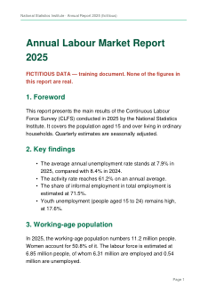

Annual Labour Market Report 2025

5 pages · 2 table(s) · 1 scanned page(s)

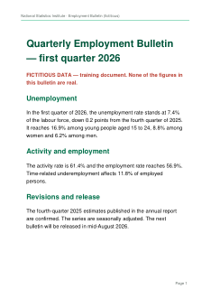

Quarterly Employment Bulletin Q1 2026

1 pages · 0 table(s)

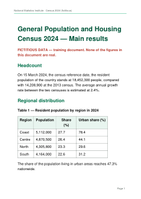

Population Census 2024

2 pages · 1 table(s)

⚠️ Some pages are **scanned** and remain invisible to the assistant. Set `USE_OCR = True` to read them.

```python
if ENV["name"] == "colab" and UPLOAD_PDF:
    from google.colab import files
    print("Select one or more PDFs…")
    uploaded = LIB.folder / "uploaded"
    uploaded.mkdir(exist_ok=True)
    for name, content in files.upload().items():
        if name.lower().endswith(".pdf"):
            (uploaded / name).write_bytes(content)
    DOCUMENTS = list(DOCUMENTS) + [str(uploaded)]

if ENV["name"] == "kaggle" and Path("/kaggle/input").exists():
    found = sorted(Path("/kaggle/input").rglob("*.pdf"))
    if found:
        show_table(pd.DataFrame([{"Available PDF": p.name, "Copy into DOCUMENTS": f'"{p}"'} for p in found[:25]]),
                   title="PDFs attached to this Kaggle notebook")

start = time.time()
added, errors = LIB.load(DOCUMENTS)
cards = "".join(
    f'<div style="border:1px solid {C["sage"]};border-radius:12px;padding:10px;background:#fff;width:190px;">'
    f'{thumbnail_html(d.data, 1, dpi=40, width=168, caption="")}'
    f'<div style="font-weight:700;font-size:13px;margin-top:4px;">{_html.escape(d.short)}</div>'
    f'<div style="font-size:11.5px;color:{C["slate"]};">{d.pages} pages · '
    f'{sum(e.type == "table" for e in d.elements)} table(s)'
    + (f' · <span style="color:{C["brick"]};">{len(d.scanned_pages)} scanned page(s)</span>' if d.scanned_pages else "")
    + '</div></div>' for d in LIB.documents)
display(HTML(f'{_CSS}<div class="rg"><div class="rg-title">📚 {len(LIB.documents)} document(s) loaded '
             f'in {time.time() - start:.1f} s</div><div style="display:flex;gap:10px;flex-wrap:wrap;">{cards}</div></div>'))
for name, why in errors:
    callout(f"<b>{_html.escape(name)}</b> skipped: {_html.escape(why)}", "error")
if errors and not LIB.documents:
    callout("No document could be loaded. If a website refused the download (HTTP 403), fetch the PDF in your "
            "browser, then set <code>UPLOAD_PDF = True</code> (Colab) or put the file path in <code>DOCUMENTS</code>.",
            "warning")
if any(d.scanned_pages for d in LIB.documents) and not USE_OCR:
    callout("Some pages are <b>scanned</b> and remain invisible to the assistant. "
            "Set <code>USE_OCR = True</code> to read them.", "warning")
```

Express track

A2 · Prepare the assistant

Splitting, search index and automatic calibration of the confidence threshold.

```python
start = time.time()
LIB.index()
model_label = f"{LLM.name} · {LLM.model}" if LLM.available else "extractive mode (no model)"
display(HTML(
    f'{_CSS}<div class="rg" style="display:flex;gap:10px;flex-wrap:wrap;">'
    + "".join(f'<div style="flex:1;min-width:150px;background:#fff;border:1px solid {C["sage"]};border-radius:12px;padding:12px 16px;">'
              f'<div style="font-size:12px;color:{C["slate"]};font-weight:600;">{t}</div>'
              f'<div style="font-size:26px;font-weight:800;color:{C["dark_green"]};line-height:1.25;">{v}</div>'
              f'<div style="font-size:11.5px;color:{C["slate"]};">{s}</div></div>'
              for t, v, s in [("Documents", len(LIB.documents), f"{sum(d.pages for d in LIB.documents)} pages in total"),
                              ("Passages", len(LIB.passages), f"{len(LIB.units)} search units · {time.time() - start:.1f} s"),
                              ("Confidence threshold", f"{LIB.threshold:.2f}", "calibrated automatically"),
                              ("Chunking", CHUNKING_LEVELS[CHUNK_STRATEGY][0].split(" · ")[0],
                               CHUNKING_LEVELS[CHUNK_STRATEGY][0].split(" · ")[1]),
                              ("Reranking", LIB.reranker.name.split(" · ")[0], LIB.reranker.name.split(" · ")[1]),
                              ("Writing", "model" if LLM.available else "excerpts", model_label)])
    + '</div>'))
show_pipeline()
if LIB.semantic.mode != "embeddings":
    callout(f"Semantic search: <b>{LIB.semantic.name}</b> — it matches spellings, not meaning. "
            "A neural model bridges your users' words and the report's: set <code>INSTALL_EMBEDDINGS = True</code> "
            "(one download of about 470 MB, then cached).", "warning")
```

```
  23 passages / 59 search units indexed in 18.3 s (Embeddings · paraphrase-multilingual-MiniLM-L12-v2) · 1 acronyms and 175 words learned · calibrating the threshold…
  threshold 0.47 calibrated in 1.2 s
```

Documents

3

8 pages in total

Passages

23

59 search units · 19.5 s

Confidence threshold

0.47

calibrated automatically

Chunking

5

Two granularities, tables and context

Reranking

2

Coverage, density and answer type

Writing

excerpts

extractive mode (no model)

🔗 The RAG chain, as configured right now

STEP 1

Question

typed by the user

STEP 2

Follow-up

rewritten as a standalone question

STEP 3

Spelling

words the documents never use are corrected

STEP 4

Normalisation

lower case, accents, stems, question words removed

STEP 5

Expansion

glossary + acronyms learned from the documents

STEP 6

BM25

exact words, on every search unit

59 units

STEP 7

Semantic

meaning, on every search unit

Embeddings · paraphrase-multilingual-MiniLM-L12-v2

STEP 8

Fusion

the two rankings merged (RRF)

STEP 9

Reranking

order decided by the level you chose

2 · Coverage, density and answer type

STEP 10

Windows → passages

each unit gives back the passage to read

STEP 11

Guardrails

threshold, year check, refusal

threshold 0.47

STEP 12

Answer

written by the model, or extracted

extractive mode

STEP 13

Checks

figures, missing terms, filter

Chunking: **5 · Two granularities, tables and context** · Reranking: **2 · Coverage, density and answer type** · Passages given to the answer: **4**

> 💡 **What these cards mean.** **Documents** and **Passages**: what was read and how it was cut. **Confidence threshold**: below this score the assistant declines (B5). **Chunking** and **Reranking**: the two levels that decide the quality of the answers — part B compares them and lets you change them. **Writing**: *model* if a language model writes the answers, *excerpts* in extractive mode.

> The diagram below is the **whole chain**, as configured right now. Part B4 traces a real question through it.

Express track

A3 · Ask a question

Change the question between quotes, then run the cell again.

```python
# 🧪 Your turn: replace the question, then run the cell again.
_ = ask(suggested_questions()[0])
```

❓ What is the unemployment rate for women in the Coast region?

ANSWERconfidence 1.00extractivefigures checked 8/811:37:59 · 0.06 s

Table 2 — Unemployment rate by region in 2025 (%): Coast — Men: 8.1; Women: 11.2; Total: 9.6. Centre — Men: 6.4; Women: 8.9; Total: 7.6. <sup>1</sup>

**Sources (4)**

page 2

**[1]** Annual Labour Market Report 2025**5. Unemployment** · p. 2, 3 · table · confidence 1.00  
“Table 2 — Unemployment rate by region in 2025 (%) Coast — Men: 8.1; Women: 11.2; Total: 9.6. Centre — Men: 6.4; Women: 8.9; Total: 7.6. North — Men: 5.9; Women: 8.0; Total: 6.9. South — Men: 6.2; Women: 8.7; Total: 7.4.…”

page 2

**[2]** Annual Labour Market Report 2025**5. Unemployment** · p. 2 · text · confidence 0.66  
“Unemployment affects women (9.3%) more than men (6.7%). It is higher in urban areas (10.4%) than in rural areas (5.2%). Table 2 details the unemployment rate by region.…”

**[3]** Population Census 2024**Regional distribution** · p. 1 · table · confidence 0.52  
“Table 1 — Resident population by region in 2024 Coast — Population: 5,112,000; Share (%): 27.7; Urban share (%): 78.4. Centre — Population: 4,870,500; Share (%): 26.4; Urban share (%): 44.1. North — Population: 4,305,800…”

**[4]** Quarterly Employment Bulletin Q1 2026**Unemployment** · p. 1 · text · confidence 0.48  
“In the first quarter of 2026, the unemployment rate stands at 7.4% of the labour force, down 0.2 points from the fourth quarter of 2025. It reaches 16.9% among young people aged 15 to 24, 8.8% among women and 6.2% among …”

```python
# A follow-up question: the assistant remembers the previous one.
_ = ask("And for men?" if DOCUMENTS == ["example"] else "And in more detail?")
```

❓ And for men?

ANSWERconfidence 1.00extractivefigures checked 8/811:37:59 · 0.06 s

🧠 Understood as: *What is the unemployment rate for men in the Coast region?* (rules)

Table 2 — Unemployment rate by region in 2025 (%): Coast — Men: 8.1; Women: 11.2; Total: 9.6. Centre — Men: 6.4; Women: 8.9; Total: 7.6. <sup>1</sup>

**Sources (4)**

page 2

**[1]** Annual Labour Market Report 2025**5. Unemployment** · p. 2, 3 · table · confidence 1.00  
“Table 2 — Unemployment rate by region in 2025 (%) Coast — Men: 8.1; Women: 11.2; Total: 9.6. Centre — Men: 6.4; Women: 8.9; Total: 7.6. North — Men: 5.9; Women: 8.0; Total: 6.9. South — Men: 6.2; Women: 8.7; Total: 7.4.…”

page 2

**[2]** Annual Labour Market Report 2025**5. Unemployment** · p. 2 · text · confidence 0.67  
“Unemployment affects women (9.3%) more than men (6.7%). It is higher in urban areas (10.4%) than in rural areas (5.2%). Table 2 details the unemployment rate by region.…”

**[3]** Population Census 2024**Regional distribution** · p. 1 · table · confidence 0.51  
“Table 1 — Resident population by region in 2024 Coast — Population: 5,112,000; Share (%): 27.7; Urban share (%): 78.4. Centre — Population: 4,870,500; Share (%): 26.4; Urban share (%): 44.1. North — Population: 4,305,800…”

**[4]** Quarterly Employment Bulletin Q1 2026**Unemployment** · p. 1 · text · confidence 0.49  
“In the first quarter of 2026, the unemployment rate stands at 7.4% of the labour force, down 0.2 points from the fourth quarter of 2025. It reaches 16.9% among young people aged 15 to 24, 8.8% among women and 6.2% among …”

> 🚀 **Express track: that's it!** Now go to **part C** to use the chat interface, in the notebook or on the web.

PART B

🔬 In-depth track

Understand each building block, see its effect, adapt it to your documents.

In-depth track

B1 · Diagnose the PDFs

Check, page by page, that the text can really be extracted.

A **scanned** page only contains an image: without OCR, the assistant ignores it **without saying so**. It will reply "information not available" although the information is in the document. This diagnosis takes a second and avoids that trap.

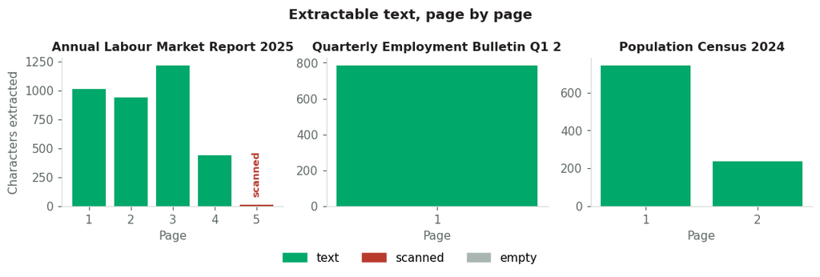

📚 Documents in the library

| No. | Document | File | Pages | Scanned pages | Tables | Passages |
| --- | --- | --- | --- | --- | --- | --- |
| 0 | Annual Labour Market Report 2025 (fictitious) | labour_market_report_2025_fictitious.pdf | 5 | 5 | 2 | 14 |
| 1 | Quarterly Employment Bulletin Q1 2026 (fictitious) | employment_bulletin_Q1_2026_fictitious.pdf | 1 | — | 0 | 4 |
| 2 | Population Census 2024 (fictitious) | census_2024_fictitious.pdf | 2 | — | 1 | 5 |

```python
colours = {"text": C["green"], "scanned": C["brick"], "empty": C["grey"]}
n = len(LIB.documents)
fig, axes = plt.subplots(1, n, figsize=(max(7.5, 3.3 * n), 3.0), squeeze=False)
for ax, d in zip(axes[0], LIB.documents):
    diag = d.diagnosis
    ax.bar(diag["Page"], diag["Characters"].clip(lower=15), color=[colours[s] for s in diag["Status"]])
    for p in d.scanned_pages:
        ax.text(p, diag["Characters"].max() * 0.08, "scanned", ha="center", rotation=90, color=C["brick"],
                fontweight="bold", fontsize=8.5)
    ax.set_title(d.short[:34], fontsize=10.5)
    pages = diag["Page"]
    ax.set_xticks(pages if len(pages) <= 20 else np.linspace(1, len(pages), 8, dtype=int))
    ax.set_xlabel("Page")
axes[0][0].set_ylabel("Characters extracted")
from matplotlib.patches import Patch
fig.legend(handles=[Patch(color=v, label=k) for k, v in colours.items()], loc="lower center", ncol=3,
           bbox_to_anchor=(0.5, -0.08))
fig.suptitle("Extractable text, page by page", fontweight="bold", color=C["ink"])
plt.tight_layout()
fig.savefig(OUTPUT_DIR / "page_diagnosis.png", dpi=160, bbox_inches="tight")
plt.show()
show_table(LIB.summary(), title="📚 Documents in the library")
```

In-depth track

B2 · Extract the structure

Headings, repeated headers, hyphenated words, tables and OCR.

| Operation | Principle | Why |
| --- | --- | --- |
| **Detect headings** | A line written clearly larger than the body text | Each passage knows its **section** |
| **Remove running headers and footers** | A line repeated at the top or bottom of at least half the pages | "Page 3" pollutes every passage |
| **Re-join hyphenated words** | "statis-⏎tics" → "statistics" | Search finds the whole word |
| **Linearise tables** | Each row becomes "Label — column: value; …" | A number on its own is meaningless |
| **OCR** (optional) | Text recognition on scanned pages | Makes scanned pages visible |

**NFKC** normalisation also replaces typographic ligatures ("ﬁ", "ﬀ") with ordinary letters: without it, "ﬁle" would never match "file".

The page below shows what the extractor recognised: **green** for headings, **grey** for paragraphs, **ochre** for tables, **red strikethrough** for removed headers and footers.

🔍 Annual Labour Market Report 2025 · page 2 as seen by the extractor

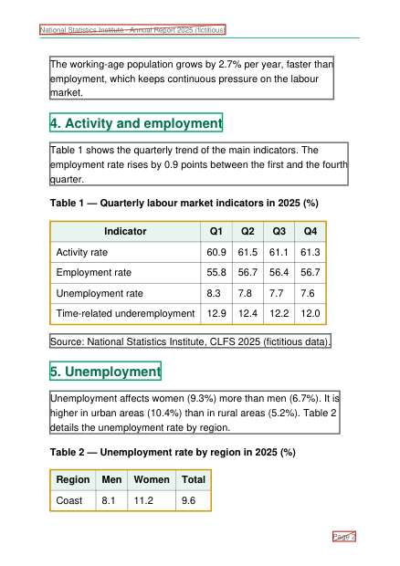

🧭 Outline detected

📘 Annual Labour Market Report p. 1

▸ 1. Foreword p. 1

▸ 2. Key findings p. 1

▸ 3. Working-age population p. 1

▸ 4. Activity and employment p. 2

▸ 5. Unemployment p. 2

▸ 6. Informal employment p. 3

▸ 7. Methodology p. 3

▸ 8. Release and confidentiality p. 3

▸ 9. Glossary p. 4

The table as read…

| Indicator | Q1 | Q2 | Q3 | Q4 |
| --- | --- | --- | --- | --- |
| Activity rate | 60.9 | 61.5 | 61.1 | 61.3 |
| Employment rate | 55.8 | 56.7 | 56.4 | 56.7 |
| Unemployment rate | 8.3 | 7.8 | 7.7 | 7.6 |
| Time-related underemployment | 12.9 | 12.4 | 12.2 | 12.0 |

… and as indexed

```
Table 1 — Quarterly labour market indicators in 2025 (%)
Activity rate — Q1: 60.9; Q2: 61.5; Q3: 61.1; Q4: 61.3.
Employment rate — Q1: 55.8; Q2: 56.7; Q3: 56.4; Q4: 56.7.
Unemployment rate — Q1: 8.3; Q2: 7.8; Q3: 7.7; Q4: 7.6.
Time-related underemployment — Q1: 12.9; Q2: 12.4; Q3: 12.2; Q4: 12.0.
```

What the extraction produced, document by document

| Document | Headings | Paragraphs | Tables | OCR paragraphs | Headers removed | Contents lines dropped |
| --- | --- | --- | --- | --- | --- | --- |
| Annual Labour Market Report 2025 | 10 | 17 | 2 | 0 | 9 | 0 |
| Quarterly Employment Bulletin Q1 2026 | 4 | 4 | 0 | 0 | 2 | 0 |
| Population Census 2024 | 4 | 4 | 1 | 0 | 4 | 0 |

```python
def annotated_page(d, number, dpi=75):
    doc = pymupdf.open("pdf", d.data)
    page = doc[number - 1]
    styles = {"heading": (0.0, 0.66, 0.42), "paragraph": (0.37, 0.41, 0.39),
              "table": (0.83, 0.60, 0.0), "ocr": (0.05, 0.49, 0.53)}
    for e in d.elements:
        if e.page == number:
            page.draw_rect(pymupdf.Rect(e.box), color=styles[e.type], width=1.4)
    height = page.rect.height
    for l in page_lines(page):
        if (l["box"].y1 < height * 0.1 or l["box"].y0 > height * 0.9) and not any(
                e.page == number and pymupdf.Rect(e.box).intersects(l["box"]) for e in d.elements):
            page.draw_rect(l["box"], color=(0.72, 0.23, 0.18), width=1.2)
            page.draw_line(l["box"].bl, l["box"].tr, color=(0.72, 0.23, 0.18), width=0.8)
    return base64.b64encode(page.get_pixmap(dpi=dpi).tobytes("png")).decode()

d_demo = next((d for d in LIB.documents if any(e.type == "table" for e in d.elements)), LIB.documents[0])
tab = next((e for e in d_demo.elements if e.type == "table"), None)
demo_page = tab.page if tab else 1
block = ""
if tab:
    df_t = pd.DataFrame(tab.table["rows"], columns=tab.table["headers"][:len(tab.table["rows"][0])])
    block = (f'<div class="rg-title" style="margin-top:10px;">The table as read…</div>'
             f'{df_t.to_html(index=False, classes="rg-t", border=0)}'
             f'<div class="rg-title" style="margin-top:10px;">… and as indexed</div>'
             f'<pre style="background:{C["mist"]};padding:10px;border-radius:8px;white-space:pre-wrap;font-size:12px;'
             f'color:{C["ink"]};">{_html.escape(tab.text)}</pre>')
headings = [e for e in d_demo.elements if e.type == "heading"]
outline = "".join(f'<div style="margin-left:{(e.level - 1) * 16}px;">{"📘" if e.level == 1 else "▸"} {_html.escape(e.text[:70])} '
                  f'<span style="color:{C["slate"]};font-size:11px;">p. {e.page}</span></div>'
                  for e in headings[:25])
if len(headings) > 25:
    outline += f'<div style="color:{C["slate"]};">… and {len(headings) - 25} more headings</div>'
display(HTML(
    f'{_CSS}<div class="rg rg-card"><div class="rg-title">🔍 {_html.escape(d_demo.short)} · page {demo_page} as seen by the extractor</div>'
    f'<div style="display:flex;gap:20px;flex-wrap:wrap;align-items:flex-start;">'
    f'<img src="data:… demo_page)}" style="width:320px;border:1px solid {C["sage"]};border-radius:6px;">'
    f'<div style="flex:1;min-width:280px;font-size:13px;"><div class="rg-title">🧭 Outline detected</div>'
    f'<div style="line-height:1.6;">{outline}</div>{block}</div></div></div>'))
show_table(pd.DataFrame([{"Document": d.short, "Headings": sum(e.type == "heading" for e in d.elements),
                          "Paragraphs": sum(e.type == "paragraph" for e in d.elements),
                          "Tables": sum(e.type == "table" for e in d.elements),
                          "OCR paragraphs": sum(e.type == "ocr" for e in d.elements),
                          "Headers removed": d.info["headers removed"],
                          "Contents lines dropped": d.info.get("contents lines dropped", 0)} for d in LIB.documents]),
           title="What the extraction produced, document by document")
```

🧪 **Your turn.** Set `REMOVE_HEADERS = False` or `EXTRACT_TABLES = False`, then run again from A1. To read the scanned annex of the annual report, set `USE_OCR = True`.

In-depth track

B3 · Split into passages

Passages that keep their document, section, pages and position.

Chunking is the single decision that most affects the answers. Cut too small and a passage no longer contains enough to answer; cut too large and the search can no longer tell passages apart. The notebook offers **five levels**, from the naive baseline to the one that measures best. Change `CHUNK_STRATEGY` in the settings and run part A again.

| `CHUNK_STRATEGY` | What it does | What it costs you |
| --- | --- | --- |
| `"fixed"` | **1 · Fixed blocks.** Cuts every `MAX_CHARS` characters. What almost every tutorial does. | Sentences, tables and headings are cut in the middle. A passage does not know which section it belongs to. |
| `"sentences"` | **2 · Sentence windows.** Groups N whole sentences, sliding. | Nothing is cut mid-sentence, but the passages are short and section-blind: the search finds fragments that cannot answer on their own. |
| `"sections"` | **3 · Structural passages.** Follows the headings found in part B2; each table is a passage of its own; the heading path travels with the text. | The unit of search is also the unit of reading, so one long section competes as a single block. |
| `"hybrid"` | **4 · Two granularities.** Indexes the structural passages **and** small sentence windows pointing back to them. | Twice the units to index (a few seconds more). |
| `"smart"` | **5 · Two granularities, tables and context.** Adds every table row as its own unit, and sends the neighbouring passages of the section along with the answer. | The most units and the slowest indexing — still only seconds on an 80-page report. |

### The five rules that levels 3 to 5 obey

| Rule | Setting | Why |
| --- | --- | --- |
| Whole sentences, up to a size limit | `MAX_CHARS = 700` | A cut sentence can be retrieved but not quoted |
| One sentence repeated between passages | `OVERLAP_SENTENCES = 1` | The answer often sits astride a boundary |
| Short passages merged with the previous one | `MIN_CHARS = 280` | An isolated line has no context and answers nothing |
| Full heading path in the search text | — | "2. Strategy › 2.4 Focus Areas" separates sections with similar wording |
| Tables kept apart, rows carrying their caption | `EXTRACT_TABLES` | A number is meaningless without its row and column labels |

> 💡 **Measured, not assumed.** On the two institutional reports used to tune this notebook (66 and 81 pages, 12 questions with known answers):

> | Level | Answer in the context | Right passage first | |---|:-:|:-:| | 1 · Fixed blocks | 11/12 | 8/12 | | 2 · Sentence windows | 12/12 | **6/12** | | 3 · Structural passages | 11/12 | 10/12 | | 4 · Two granularities | **12/12** | **10/12** | | 5 · Two granularities, tables and context | **12/12** | **10/12** |

> The lesson that surprises most people: **indexing small chunks alone is the worst option** (level 2). A two-sentence window rarely contains all the words of a question, so the lexical search loses it. Small chunks help only when a larger passage stands behind them — that is levels 4 and 5.

> ⚠️ These numbers come from **two** reports and **twelve** questions. They are enough to separate very different strategies, not to prove that one level beats another by a single question. Run the benchmark below on your own documents.

```python
sample = LIB.passages[:40]
show_table(pd.DataFrame([{"No.": p.id, "Document": p.doc[:30], "Section": (p.section or "—")[:36],
                          "Pages": ", ".join(map(str, p.pages)), "Kind": p.kind, "Characters": len(p.text),
                          "Start": _html.escape(p.text[:80].replace(chr(10), " ")) + "…"} for p in sample]),
           title=f"✂️ {len(LIB.passages)} indexed passages",
           note=("First 40 shown; the full list is exported to passages.csv in part D."
                 if len(LIB.passages) > 40 else None))
lengths = [len(p.text) for p in LIB.passages]
show_table(pd.DataFrame([{"Context passages": len(LIB.passages), "Search units": len(LIB.units),
                          "Average passage length": int(np.mean(lengths)),
                          "Table passages": sum(p.kind == "table" for p in LIB.passages),
                          "Strategy": CHUNK_STRATEGY, "Acronyms learned": len(ACRONYMS)}]),
           title="Index at a glance")
```

✂️ 23 indexed passages

| No. | Document | Section | Pages | Kind | Characters | Start |
| --- | --- | --- | --- | --- | --- | --- |
| 0 | Annual Labour Market Report 20 | — | 1 | text | 81 | FICTITIOUS DATA — training document. None of the figures in this report are real… |
| 1 | Annual Labour Market Report 20 | 1. Foreword | 1 | text | 256 | This report presents the main results of the Continuous Labour Force Survey (CLF… |
| 2 | Annual Labour Market Report 20 | 2. Key findings | 1 | text | 296 | • The average annual unemployment rate stands at 7.9% in 2025, compared with 8.… |
| 3 | Annual Labour Market Report 20 | 3. Working-age population | 1, 2 | text | 345 | In 2025, the working-age population numbers 11.2 million people. Women account f… |
| 4 | Annual Labour Market Report 20 | 4. Activity and employment | 2 | text | 139 | Table 1 shows the quarterly trend of the main indicators. The employment rate ri… |
| 5 | Annual Labour Market Report 20 | 4. Activity and employment | 2 | table | 297 | Table 1 — Quarterly labour market indicators in 2025 (%) Activity rate — Q1: 60.… |
| 6 | Annual Labour Market Report 20 | 4. Activity and employment | 2 | text | 67 | Source: National Statistics Institute, CLFS 2025 (fictitious data).… |
| 7 | Annual Labour Market Report 20 | 5. Unemployment | 2 | text | 168 | Unemployment affects women (9.3%) more than men (6.7%). It is higher in urban ar… |
| 8 | Annual Labour Market Report 20 | 5. Unemployment | 2, 3 | table | 219 | Table 2 — Unemployment rate by region in 2025 (%) Coast — Men: 8.1; Women: 11.2;… |
| 9 | Annual Labour Market Report 20 | 5. Unemployment | 3 | text | 121 | The average job search lasts 14 months. One unemployed person in three has been … |
| 10 | Annual Labour Market Report 20 | 6. Informal employment | 3 | text | 258 | Informal employment covers jobs with neither social protection nor a written con… |
| 11 | Annual Labour Market Report 20 | 7. Methodology | 3 | text | 451 | The survey is based on a two-stage random sample. Six hundred enumeration areas … |
| 12 | Annual Labour Market Report 20 | 8. Release and confidentiality | 3, 4 | text | 231 | Quarterly results are published 45 days after the end of the reference quarter. … |
| 13 | Annual Labour Market Report 20 | 9. Glossary | 4 | text | 319 | Unemployed person: a person aged 15 or over, without work, available for work an… |
| 14 | Quarterly Employment Bulletin | — | 1 | text | 83 | FICTITIOUS DATA — training document. None of the figures in this bulletin are re… |
| 15 | Quarterly Employment Bulletin | Unemployment | 1 | text | 224 | In the first quarter of 2026, the unemployment rate stands at 7.4% of the labour… |
| 16 | Quarterly Employment Bulletin | Activity and employment | 1 | text | 129 | The activity rate is 61.4% and the employment rate reaches 56.9%. Time-related u… |
| 17 | Quarterly Employment Bulletin | Revisions and release | 1 | text | 170 | The fourth-quarter 2025 estimates published in the annual report are confirmed. … |
| 18 | Population Census 2024 | — | 1 | text | 83 | FICTITIOUS DATA — training document. None of the figures in this document are re… |
| 19 | Population Census 2024 | Headcount | 1 | text | 235 | On 15 March 2024, the census reference date, the resident population of the coun… |
| 20 | Population Census 2024 | Regional distribution | 1 | table | 332 | Table 1 — Resident population by region in 2024 Coast — Population: 5,112,000; S… |
| 21 | Population Census 2024 | Regional distribution | 1 | text | 75 | The share of the population living in urban areas reaches 47.3% nationwide.… |
| 22 | Population Census 2024 | Households | 2 | text | 161 | The census counts 3,618,100 ordinary households. The average household size is 5… |

Index at a glance

| Context passages | Search units | Average passage length | Table passages | Strategy | Acronyms learned |
| --- | --- | --- | --- | --- | --- |
| 23 | 59 | 206 | 3 | smart | 1 |

#### The same document under each level

```python
compare_chunking()
```

✂️ The five levels on “Annual Labour Market Report 2025”

| Level | Passages | Search units | Average length | Knows its section | Seconds | First passage |
| --- | --- | --- | --- | --- | --- | --- |
| 1 · Fixed blocks | 6 | 6 | 647 | — | 0.0 | Annual Labour Market Report FICTITIOUS DATA — training document. None of the figures in this report are real. 1. Foreword This report presents the mai… |
| 2 · Sentence windows | 40 | 40 | 125 | — | 0.0 | Foreword This report presents the main results of the Continuous Labour Force Survey (CLFS) conducted in 2025 by the National Statistics Institute. It… |
| 3 · Structural passages | 14 | 14 | 232 | ✅ | 0.0 | This report presents the main results of the Continuous Labour Force Survey (CLFS) conducted in 2025 by the National Statistics Institute. It covers t… |
| 4 · Two granularities | 14 | 27 | 232 | ✅ | 0.0 | This report presents the main results of the Continuous Labour Force Survey (CLFS) conducted in 2025 by the National Statistics Institute. It covers t… |
| 5 · Two granularities, tables and context | 14 | 37 | 232 | ✅ | 0.0 | This report presents the main results of the Continuous Labour Force Survey (CLFS) conducted in 2025 by the National Statistics Institute. It covers t… |

Levels 1 and 2 ignore headings and tables, so a passage no longer knows where it comes from. Levels 4 and 5 index a second, finer granularity — that is why they have more search units than passages.

#### Choose with evidence, not with faith

`benchmark()` re-indexes your collection with each combination and measures it. It uses, in order of preference:

1. **your own questions**, if you filled `EVALUATION_QUESTIONS` in the settings — by far the most meaningful:

   ```
   EVALUATION_QUESTIONS = [
       ("How many dimensions does the maturity model have?", ["12 dimensions"]),
       ("Which countries took part in the diagnostic?", ["Tunisia", "Senegal"]),
   ]
   ```

   Each entry is a question and the text that must appear in the passages handed to the model.
2. otherwise **probe questions built from the documents themselves**: the words of one sentence must bring back a *later* sentence of the same topic. A chunking that cuts a topic in two fails. It is a proxy, not a verdict.

Indexing happens once per combination, so five levels on an 80-page report take about half a minute — and far longer with neural embeddings.

```python
# 🧪 Your turn: write the questions that matter to you. This is what a real evaluation set looks like.
if DOCUMENTS == ["example"] and not EVALUATION_QUESTIONS:
    EVALUATION_QUESTIONS = [
        ("What is the unemployment rate in the second quarter?", ["Q2: 7.8"]),
        ("What is the population of the Centre region?", ["4,870,500"]),
        ("What is the share of informal employment?", ["71.5"]),
        ("What is the average household size?", ["5.1 people"]),
        ("Can researchers get access to the microdata?", ["secure data access"]),
        ("When will the next employment bulletin be released?", ["mid-August 2026"]),
        ("What is the average job search duration?", ["14 months"]),
        ("How is unit non-response corrected?", ["reweighting"]),
    ]

BENCHMARK = benchmark(chunking=("fixed", "sentences", "sections", "hybrid", "smart"),
                      reranking=("smart",), show_questions=True)
```

The 8 questions used by the benchmark

| Question | Expected in the context |
| --- | --- |
| What is the unemployment rate in the second quarter? | Q2: 7.8 |
| What is the population of the Centre region? | 4,870,500 |
| What is the share of informal employment? | 71.5 |
| What is the average household size? | 5.1 people |
| Can researchers get access to the microdata? | secure data access |
| When will the next employment bulletin be released? | mid-August 2026 |
| What is the average job search duration? | 14 months |
| How is unit non-response corrected? | reweighting |

```
  10 passages / 10 search units indexed in 0.2 s (Embeddings · paraphrase-multilingual-MiniLM-L12-v2) · 1 acronyms and 187 words learned · calibrating the threshold…
  threshold 0.48 calibrated in 0.6 s
  57 passages / 57 search units indexed in 0.5 s (Embeddings · paraphrase-multilingual-MiniLM-L12-v2) · 1 acronyms and 180 words learned · calibrating the threshold…
  threshold 0.32 calibrated in 1.1 s
  23 passages / 23 search units indexed in 0.3 s (Embeddings · paraphrase-multilingual-MiniLM-L12-v2) · 1 acronyms and 175 words learned · calibrating the threshold…
  threshold 0.52 calibrated in 0.9 s
  23 passages / 44 search units indexed in 0.6 s (Embeddings · paraphrase-multilingual-MiniLM-L12-v2) · 1 acronyms and 175 words learned · calibrating the threshold…
  threshold 0.52 calibrated in 1.3 s
  23 passages / 59 search units indexed in 0.0 s (Embeddings · paraphrase-multilingual-MiniLM-L12-v2) · 1 acronyms and 175 words learned · calibrating the threshold…
  threshold 0.47 calibrated in 0.4 s
  23 passages / 59 search units indexed in 0.0 s (Embeddings · paraphrase-multilingual-MiniLM-L12-v2) · 1 acronyms and 175 words learned · calibrating the threshold…
  threshold 0.47 calibrated in 1.0 s
```

🏁 Benchmark on your own documents

| Chunking | Reranking | Passages | Units | Answer in the context | Right passage first | Indexing (s) | Per question (ms) | Best |
| --- | --- | --- | --- | --- | --- | --- | --- | --- |
| 1 · Fixed blocks | 2 · Coverage, density and answer type | 10 | 10 | 8/8 | 7/8 | 0.9 | 17 |  |
| 2 · Sentence windows | 2 · Coverage, density and answer type | 57 | 57 | 8/8 | 8/8 | 1.5 | 62 | 🏆 |
| 3 · Structural passages | 2 · Coverage, density and answer type | 23 | 23 | 8/8 | 8/8 | 1.3 | 62 | 🏆 |
| 4 · Two granularities | 2 · Coverage, density and answer type | 23 | 44 | 8/8 | 8/8 | 1.9 | 60 | 🏆 |
| 5 · Two granularities, tables and context | 2 · Coverage, density and answer type | 23 | 59 | 8/8 | 8/8 | 0.4 | 32 | 🏆 |

Measured on this collection only: re-run it on yours before trusting any ranking. A combination that wins by one question is a tie, not a winner.

In-depth track

B4 · The search chain

Thirteen steps between the question and the answer — and the four levels of reranking.

### The thirteen steps, and where you can act

| # | Step | What it does | Setting |
| --- | --- | --- | --- |
| 1 | **Question** | as typed by the user | — |
| 2 | **Follow-up** | "And for men?" is rewritten as a standalone question (B7) | `MODEL_FOLLOW_UP` |
| 3 | **Spelling** | a word the documents never use is replaced by the closest one they do: *coutries* → *countries* | — |
| 4 | **Normalisation** | lower case, accents, word stems; question words ("number of", "list", "stand for") are dropped | `STOPWORDS` |
| 5 | **Expansion** | domain glossary, plus the acronyms learned from the documents | `GLOSSARY` |
| 6 | **BM25** | exact words, over every search unit | `CHUNK_STRATEGY` |
| 7 | **Semantic** | meaning rather than words | `USE_EMBEDDINGS` |
| 8 | **Fusion** | the two rankings merged (Reciprocal Rank Fusion) | — |
| 9 | **Reranking** | the order is decided here | `RERANKING` |
| 10 | **Windows → passages** | each small unit hands back the passage a human should read | `CHUNK_STRATEGY` |
| 11 | **Guardrails** | threshold, year check, refusal (B5) | `MANUAL_THRESHOLD` |
| 12 | **Answer** | written by the model, or extracted from the passage | Groq / Ollama |
| 13 | **Checks** | figures verified, terms not found, better answer excluded by a filter (B9) | — |

Step 7 is worth a word: **without `sentence-transformers` the notebook falls back to an offline approximation (LSA on character n-grams)**, which matches spellings rather than meaning. It never fails, but it cannot bridge "participating in the assessment" and "the Bank has conducted diagnostic missions in". If your questions use your users' words rather than the report's, install the neural model — `INSTALL_EMBEDDINGS = True`.

### The four levels of reranking

The fused ranking is rarely the right order. Reranking re-scores the shortlist; `RERANKING` chooses how.

[output not shown]

> 💡 **Measured on the same two reports**, chunking fixed at level 5:

> | Reranking | Answer in the context | Right passage first | |---|:-:|:-:| | 0 · None | 10/12 | 6/12 | | 1 · Question coverage | 12/12 | 8/12 | | 2 · Coverage, density and answer type | **12/12** | **10/12** |

> The cross-encoder is missing from this table on purpose: it could not be downloaded in the environment where the notebook was tuned. Run `benchmark(reranking=("smart", "cross-encoder"))` yourself — on public benchmarks a cross-encoder usually wins, at the price of latency.

> 💡 **The glossary is yours.** Extend `GLOSSARY` (cell T4) with your users' vocabulary — "framework" → "maturity model diagnostic" on the AfDB guide, for instance. It is often the most cost-effective improvement of all, and it is the right answer when a question keeps missing because your users and your reports use different words.

```python
q = ("What was the unemployment rate in the fourth quarter of 2025?" if DOCUMENTS == ["example"]
     else f"What does the document say about: {next((e.text for d in LIB.documents for e in d.elements if e.type == 'heading' and e.level > 1), 'the main topic')}?")
show_table(pd.DataFrame([{"Question": q, "Analysed terms": ", ".join(analyse(q)),
                          "Glossary additions": "<br>".join(f"<b>{k}</b> → {t}" for k, t in expand_query(q)[1]) or "—"}]),
           title="What the search engine “sees” in a question")

def _ranking(docs):
    return [f"{p.doc[:28]}… › {p.section[:22]} ({s:.2f})" for p, s in LIB.search(q, 4, docs)]
columns = {"All documents": _ranking(None)}
for d in LIB.documents[:2]:
    columns[f"Only: {d.short[:30]}"] = _ranking([d.id])
length = max(len(v) for v in columns.values())
show_table(pd.DataFrame({"Rank": range(1, length + 1),
                         **{k: v + ["—"] * (length - len(v)) for k, v in columns.items()}}),
           title=f"Effect of the document filter · “{q}”",
           note=f"Semantic search: {LIB.semantic.name}. In brackets: the confidence.")
```

What the search engine “sees” in a question

| Question | Analysed terms | Glossary additions |
| --- | --- | --- |
| What was the unemployment rate in the fourth quarter of 2025? | unemploy, rate, fourth, quart, 2025 | **fourth quarter** → q4 |

Effect of the document filter · “What was the unemployment rate in the fourth quarter of 2025?”

| Rank | All documents | Only: Annual Labour Market Report 20 | Only: Quarterly Employment Bulletin |
| --- | --- | --- | --- |
| 1 | Annual Labour Market Report … › 4. Activity and employ (1.00) | Annual Labour Market Report … › 4. Activity and employ (1.00) | Quarterly Employment Bulleti… › Unemployment (1.00) |
| 2 | Quarterly Employment Bulleti… › Unemployment (1.00) | Annual Labour Market Report … › 4. Activity and employ (0.83) | Quarterly Employment Bulleti… › Revisions and release (0.69) |
| 3 | Annual Labour Market Report … › 4. Activity and employ (0.83) | Annual Labour Market Report … › 5. Unemployment (0.45) | Quarterly Employment Bulleti… › Activity and employmen (0.35) |
| 4 | Quarterly Employment Bulleti… › Revisions and release (0.69) | Annual Labour Market Report … › 5. Unemployment (0.45) | Quarterly Employment Bulleti… › (0.20) |

Semantic search: Embeddings · paraphrase-multilingual-MiniLM-L12-v2. In brackets: the confidence.

#### See the chain, then trace one question through it

`show_pipeline()` draws the chain as it is configured right now. `explain("…")` runs one question through every step and shows what each step changed — the fastest way to understand *why* an answer is what it is.

```python
show_pipeline()

# 🧪 Your turn: put a question of yours here — ideally one that disappointed you.
_ = explain(suggested_questions()[0])
```

🔗 The RAG chain, as configured right now

STEP 1

Question

typed by the user

STEP 2

Follow-up

rewritten as a standalone question

STEP 3

Spelling

words the documents never use are corrected

STEP 4

Normalisation

lower case, accents, stems, question words removed

STEP 5

Expansion

glossary + acronyms learned from the documents

STEP 6

BM25

exact words, on every search unit

59 units

STEP 7

Semantic

meaning, on every search unit

Embeddings · paraphrase-multilingual-MiniLM-L12-v2

STEP 8

Fusion

the two rankings merged (RRF)

STEP 9

Reranking

order decided by the level you chose

2 · Coverage, density and answer type

STEP 10

Windows → passages

each unit gives back the passage to read

STEP 11

Guardrails

threshold, year check, refusal

threshold 0.47

STEP 12

Answer

written by the model, or extracted

extractive mode

STEP 13

Checks

figures, missing terms, filter

Chunking: **5 · Two granularities, tables and context** · Reranking: **2 · Coverage, density and answer type** · Passages given to the answer: **4**

🔍 What is the unemployment rate for women in the Coast region?

| Question type | **other** — no special treatment |
| --- | --- |
| 4 · Terms kept | unemploy (1.1), rate (0.9), women (1.7), coast (2.6), region (1.4) |
| 5 · Expansion | nothing to add |
| 6 · BM25 (exact words) | 1. **5. Unemployment** · p. 2 (7.34) 2. **5. Unemployment** · p. 2 (7.27) 3. **5. Unemployment** · p. 2 (5.87) 4. **5. Unemployment** · p. 2 (5.45) |
| 7 · Embeddings · paraphrase-multilingual-MiniLM-L12-v2 | 1. **5. Unemployment** · p. 2 (0.77) 2. **5. Unemployment** · p. 2 (0.65) 3. **5. Unemployment** · p. 2 (0.65) 4. **5. Unemployment** · p. 2 (0.64) |
| 8 · Fusion | 1. **5. Unemployment** · p. 2 (0.03) 2. **5. Unemployment** · p. 2 (0.03) 3. **5. Unemployment** · p. 2 (0.03) 4. **5. Unemployment** · p. 2 (0.03) |
| 9 · Reranking · 2 · Coverage, density and answer type | 1. **5. Unemployment** · p. 2 (coverage 1.00) 2. **5. Unemployment** · p. 2 (coverage 0.69) 3. **5. Unemployment** · p. 2 (coverage 0.66) 4. **5. Unemployment** · p. 2 (coverage 0.66) |
| 10 · Passages returned | 1. Annual Labour Market Report 2025 · 5. Unemployment · pp. 2–3 2. Annual Labour Market Report 2025 · 5. Unemployment · p. 2 3. Population Census 2024 · Regional distribution · p. 1 4. Quarterly Emplo… |
| 11 · Guardrails | confidence **1.00** vs threshold **0.47** → **answer** |

❓ What is the unemployment rate for women in the Coast region?

ANSWERconfidence 1.00extractivefigures checked 8/811:38:09 · 0.05 s

Table 2 — Unemployment rate by region in 2025 (%): Coast — Men: 8.1; Women: 11.2; Total: 9.6. Centre — Men: 6.4; Women: 8.9; Total: 7.6. <sup>1</sup>

**Sources (4)**

page 2

**[1]** Annual Labour Market Report 2025**5. Unemployment** · p. 2, 3 · table · confidence 1.00  
“Table 2 — Unemployment rate by region in 2025 (%) Coast — Men: 8.1; Women: 11.2; Total: 9.6. Centre — Men: 6.4; Women: 8.9; Total: 7.6. North — Men: 5.9; Women: 8.0; Total: 6.9. South — Men: 6.2; Women: 8.7; Total: 7.4.…”

page 2

**[2]** Annual Labour Market Report 2025**5. Unemployment** · p. 2 · text · confidence 0.66  
“Unemployment affects women (9.3%) more than men (6.7%). It is higher in urban areas (10.4%) than in rural areas (5.2%). Table 2 details the unemployment rate by region.…”

**[3]** Population Census 2024**Regional distribution** · p. 1 · table · confidence 0.52  
“Table 1 — Resident population by region in 2024 Coast — Population: 5,112,000; Share (%): 27.7; Urban share (%): 78.4. Centre — Population: 4,870,500; Share (%): 26.4; Urban share (%): 44.1. North — Population: 4,305,800…”

**[4]** Quarterly Employment Bulletin Q1 2026**Unemployment** · p. 1 · text · confidence 0.48  
“In the first quarter of 2026, the unemployment rate stands at 7.4% of the labour force, down 0.2 points from the fourth quarter of 2025. It reaches 16.9% among young people aged 15 to 24, 8.8% among women and 6.2% among …”

In-depth track

B5 · Guardrails and threshold calibration

Answer only when the documents allow it.

Three guardrails decide whether the assistant may answer:

1. **Confidence threshold**: if the best passage is not relevant enough, the assistant declines **without calling the model**;
2. **Year check**: a year mentioned in the question must appear in the passages;
3. **Strict prompt**: answer only from the sources, cite them, and decline with a fixed sentence otherwise.

### How the threshold is calculated

**Confidence of a question** = weight of the question's words found in the best passage ÷ weight of all the question's words. Rare words weigh more; words found **nowhere** in the documents (such as "hospitals") weigh the most, because they signal an off-topic question.

**Calibration**: the notebook asks two series of reference questions — questions built from the **section headings** (the answer exists) and **off-topic** questions (no answer). The threshold is set just above the best off-topic score:

> **Threshold = best off-topic confidence + 0.05** (capped at 0.95)

> ⚠️ This threshold is a starting point: adjust it in the interfaces if the assistant declines too often, or not often enough. To fix it yourself: `MANUAL_THRESHOLD = 0.5`.

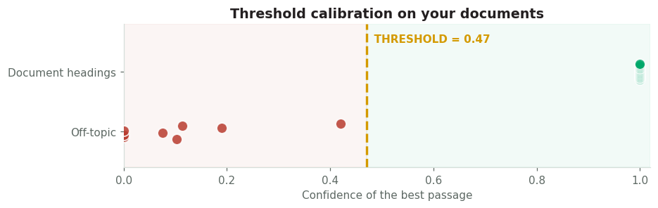

Reference questions

| Question | Answer exists | Confidence |
| --- | --- | --- |
| What does the document say about: Foreword? | True | 1.000 |
| What does the document say about: Key findings? | True | 1.000 |
| What does the document say about: Working-age population? | True | 1.000 |
| What does the document say about: Activity and employment? | True | 1.000 |
| What does the document say about: Unemployment? | True | 1.000 |
| What does the document say about: Informal employment? | True | 1.000 |
| What does the document say about: Methodology? | True | 1.000 |
| What does the document say about: Release and confidentiality? | True | 1.000 |
| What does the document say about: Glossary? | True | 1.000 |
| What does the document say about: Revisions and release? | True | 1.000 |
| What does the document say about: Headcount? | True | 1.000 |
| What does the document say about: Regional distribution? | True | 1.000 |
| What does the document say about: Households? | True | 1.000 |
| How many hospitals are there in the North region? | False | 0.420 |
| What is the national cocoa production? | False | 0.190 |
| Who wrote this year's best-selling novel? | False | 0.114 |
| Which team won the last football World Cup? | False | 0.103 |
| What is the price of maize per kilogram at the market? | False | 0.075 |
| What is the traditional recipe for couscous? | False | 0.000 |
| What will the weather be like tomorrow in the capital? | False | 0.000 |
| How many measles vaccines were administered? | False | 0.000 |

❓ What is the price of maize per kilogram?

DECLINEDconfidence 0.00guardrail11:38:10 · 0.04 s

Information not available in the documents.

Reason: confidence 0.00 below threshold 0.47

**Sources (4)**

**[1]** Population Census 2024**Households** · p. 2 · text · confidence 0.00  
“The census counts 3,618,100 ordinary households. The average household size is 5.1 people, compared with 5.4 in 2013. One household in four is headed by a woman.…”

**[2]** Population Census 2024**Headcount** · p. 1 · text · confidence 0.00  
“On 15 March 2024, the census reference date, the resident population of the country stands at 18,452,300 people, compared with 14,208,900 at the 2013 census. The average annual growth rate between the two censuses is est…”

**[3]** Annual Labour Market Report 2025**2. Key findings** · p. 1 · text · confidence 0.00  
“• The average annual unemployment rate stands at 7.9% in 2025, compared with 8.4% in 2024. • The activity rate reaches 61.2% on an annual average. • The share of informal employment in total employment is estimated at 71…”

**[4]** Annual Labour Market Report 2025**7. Methodology** · p. 3 · text · confidence 0.00  
“The survey is based on a two-stage random sample. Six hundred enumeration areas are selected with probability proportional to size, then twenty dwellings are drawn in each area, giving 12,000 dwellings per quarter. The r…”

❓ What will the unemployment rate be in 2030?

DECLINEDconfidence 0.27guardrail11:38:10 · 0.04 s

Information not available in the documents.

Reason: confidence 0.27 below threshold 0.47

**Sources (4)**

**[1]** Annual Labour Market Report 2025**5. Unemployment** · p. 2, 3 · table · confidence 0.27  
“Table 2 — Unemployment rate by region in 2025 (%) Coast — Men: 8.1; Women: 11.2; Total: 9.6. Centre — Men: 6.4; Women: 8.9; Total: 7.6. North — Men: 5.9; Women: 8.0; Total: 6.9. South — Men: 6.2; Women: 8.7; Total: 7.4.…”

**[2]** Annual Labour Market Report 2025**5. Unemployment** · p. 2 · text · confidence 0.27  
“Unemployment affects women (9.3%) more than men (6.7%). It is higher in urban areas (10.4%) than in rural areas (5.2%). Table 2 details the unemployment rate by region.…”

**[3]** Annual Labour Market Report 2025**4. Activity and employment** · p. 2 · table · confidence 0.27  
“Table 1 — Quarterly labour market indicators in 2025 (%) Activity rate — Q1: 60.9; Q2: 61.5; Q3: 61.1; Q4: 61.3. Employment rate — Q1: 55.8; Q2: 56.7; Q3: 56.4; Q4: 56.7. Unemployment rate — Q1: 8.3; Q2: 7.8; Q3: 7.7; Q4…”

**[4]** Quarterly Employment Bulletin Q1 2026**Unemployment** · p. 1 · text · confidence 0.27  
“In the first quarter of 2026, the unemployment rate stands at 7.4% of the labour force, down 0.2 points from the fourth quarter of 2025. It reaches 16.9% among young people aged 15 to 24, 8.8% among women and 6.2% among …”

```python
cal = LIB.calibration
fig, ax = plt.subplots(figsize=(8.6, 2.8))
for rank, (exists, colour) in enumerate([(False, C["brick"]), (True, C["green"])]):
    v = cal.loc[cal["Answer exists"] == exists, "Confidence"]
    ax.scatter(v, np.full(len(v), rank) + np.linspace(-0.13, 0.13, len(v)), s=95, color=colour,
               alpha=0.85, edgecolor="white", linewidth=1.2, zorder=3)
ax.axvline(LIB.threshold, color=C["ochre"], linewidth=2.2, linestyle="--")
ax.axvspan(0, LIB.threshold, color=C["brick"], alpha=0.05); ax.axvspan(LIB.threshold, 1.02, color=C["green"], alpha=0.05)
ax.text(LIB.threshold, 1.55, f"  THRESHOLD = {LIB.threshold:.2f}", color=C["ochre"], fontweight="bold", va="center")
ax.set_yticks([0, 1], ["Off-topic", "Document headings"]); ax.set_xlim(0, 1.02); ax.set_ylim(-0.6, 1.8)
ax.set_xlabel("Confidence of the best passage"); ax.set_title("Threshold calibration on your documents")
plt.tight_layout(); fig.savefig(OUTPUT_DIR / "threshold_calibration.png", dpi=160); plt.show()
show_table(cal.sort_values("Confidence", ascending=False), title="Reference questions")

for q in ["What is the price of maize per kilogram?", "What will the unemployment rate be in 2030?"]:
    LIB.show(LIB.answer(q))
```

In-depth track

B6 · Search several documents

Answers that combine several reports, with the source of each figure.

With several documents, two situations arise:

- **the question targets a specific document**: the document filter prevents a neighbouring report with similar vocabulary from slipping in;
- **the question compares** periods or documents ("change", "between", "compared with"): the assistant gathers passages from **several documents** and gives **each value with its source**.

> ⚠️ **The twin-document trap.** Two quarterly bulletins written the same way differ only by their period. Without a contextual header, the assistant may quote the wrong quarter with complete confidence.

❓ How did the unemployment rate change between the fourth quarter of 2025 and the first quarter of 2026?

ANSWERconfidence 1.00extractivefigures checked 16/1611:38:10 · 0.04 s

In the first quarter of 2026, the unemployment rate stands at 7.4% of the labour force, down 0.2 points from the fourth quarter of 2025. <sup>1</sup> — Annual Labour Market Report 2025: Table 1 — Quarterly labour market indicators in 2025 (%): Unemployment rate — Q1: 8.3; Q2: 7.8; Q3: 7.7; Q4: 7.6. Time-related underemployment — Q1: 12.9; Q2: 12.4; Q3: 12.2; Q4: 12.0. <sup>3</sup>

**Sources (4)**

page 1

**[1]** Quarterly Employment Bulletin Q1 2026**Unemployment** · p. 1 · text · confidence 1.00  
“In the first quarter of 2026, the unemployment rate stands at 7.4% of the labour force, down 0.2 points from the fourth quarter of 2025. It reaches 16.9% among young people aged 15 to 24, 8.8% among women and 6.2% among …”

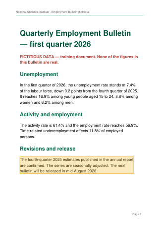

page 1

**[2]** Quarterly Employment Bulletin Q1 2026**Revisions and release** · p. 1 · text · confidence 0.55  
“The fourth-quarter 2025 estimates published in the annual report are confirmed. The series are seasonally adjusted. The next bulletin will be released in mid-August 2026.…”

**[3]** Annual Labour Market Report 2025**4. Activity and employment** · p. 2 · table · confidence 0.54  
“Table 1 — Quarterly labour market indicators in 2025 (%) Activity rate — Q1: 60.9; Q2: 61.5; Q3: 61.1; Q4: 61.3. Employment rate — Q1: 55.8; Q2: 56.7; Q3: 56.4; Q4: 56.7. Unemployment rate — Q1: 8.3; Q2: 7.8; Q3: 7.7; Q4…”

**[4]** Annual Labour Market Report 2025**4. Activity and employment** · p. 2 · text · confidence 0.47  
“Table 1 shows the quarterly trend of the main indicators. The employment rate rises by 0.9 points between the first and the fourth quarter.…”

❓ What is the youth unemployment rate?

ANSWERconfidence 1.00extractivefigures checked 3/311:38:10 · 0.03 s

• Youth unemployment (people aged 15 to 24) remains high, at 17.6%. <sup>2</sup>

**Sources (4)**

page 1

**[1]** Quarterly Employment Bulletin Q1 2026**Unemployment** · p. 1 · text · confidence 1.00  
“In the first quarter of 2026, the unemployment rate stands at 7.4% of the labour force, down 0.2 points from the fourth quarter of 2025. It reaches 16.9% among young people aged 15 to 24, 8.8% among women and 6.2% among …”

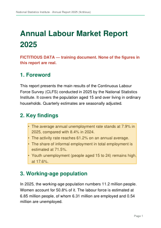

page 1

**[2]** Annual Labour Market Report 2025**2. Key findings** · p. 1 · text · confidence 1.00  
“• The average annual unemployment rate stands at 7.9% in 2025, compared with 8.4% in 2024. • The activity rate reaches 61.2% on an annual average. • The share of informal employment in total employment is estimated at 71…”

**[3]** Annual Labour Market Report 2025**9. Glossary** · p. 4 · text · confidence 1.00  
“Unemployed person: a person aged 15 or over, without work, available for work and actively seeking work during the past four weeks. Activity rate: ratio of the labour force to the working-age population. Time-related und…”

**[4]** Annual Labour Market Report 2025**5. Unemployment** · p. 2, 3 · table · confidence 0.35  
“Table 2 — Unemployment rate by region in 2025 (%) Coast — Men: 8.1; Women: 11.2; Total: 9.6. Centre — Men: 6.4; Women: 8.9; Total: 7.6. North — Men: 5.9; Women: 8.0; Total: 6.9. South — Men: 6.2; Women: 8.7; Total: 7.4.…”

💡 Several documents may answer, for different periods or scopes. Same question, restricted to “Quarterly Employment Bulletin Q1 2026”:

❓ What is the youth unemployment rate?

ANSWERconfidence 1.00extractivefigures checked 9/911:38:10 · 0.06 s

In the first quarter of 2026, the unemployment rate stands at 7.4% of the labour force, down 0.2 points from the fourth quarter of 2025. It reaches 16.9% among young people aged 15 to 24, 8.8% among women and 6.2% among men. <sup>1</sup>

**Sources (3)**

page 1

**[1]** Quarterly Employment Bulletin Q1 2026**Unemployment** · p. 1 · text · confidence 1.00  
“In the first quarter of 2026, the unemployment rate stands at 7.4% of the labour force, down 0.2 points from the fourth quarter of 2025. It reaches 16.9% among young people aged 15 to 24, 8.8% among women and 6.2% among …”

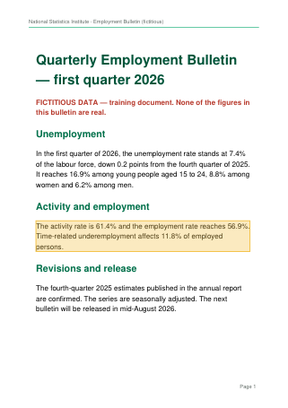

page 1

**[2]** Quarterly Employment Bulletin Q1 2026**Activity and employment** · p. 1 · text · confidence 0.16  
“The activity rate is 61.4% and the employment rate reaches 56.9%. Time-related underemployment affects 11.8% of employed persons.…”

**[3]** Quarterly Employment Bulletin Q1 2026**start** · p. 1 · text · confidence 0.00  
“FICTITIOUS DATA — training document. None of the figures in this bulletin are real.…”

```python
if DOCUMENTS == ["example"]:
    LIB.show(LIB.answer("How did the unemployment rate change between the fourth quarter of 2025 and the first quarter of 2026?"))
    q = "What is the youth unemployment rate?"
    second = next((d for d in LIB.documents if "bulletin" in d.filename.lower()), None)
else:
    q = suggested_questions()[0]
    second = LIB.documents[1] if len(LIB.documents) > 1 else None
LIB.show(LIB.answer(q))
if second is not None:
    callout(f"Several documents may answer, for different periods or scopes. "
            f"Same question, restricted to “{_html.escape(second.short)}”:", "info")
    LIB.show(LIB.answer(q, docs=[second.id]))
```

In-depth track

B7 · Conversation memory

Understanding “and for men?” thanks to the previous question.

A follow-up question makes no sense on its own: "And for men?" contains no indicator. Before searching, the assistant **rewrites it as a standalone question**:

| Method | Principle | When |
| --- | --- | --- |
| **By the model** | The model receives the last turns and rewrites the question | A model is available and `MODEL_FOLLOW_UP = True` |
| **By rules** | The previous question is reused and the value that changes (region, sex, quarter, year, area, age, indicator) is **replaced** | Without a model, or as a fallback |

The rewrite is **always displayed** ("🧠 Understood as: …") so the user can check it.

> ⚠️ **Memory can be wrong.** If the user changes topic with a very short question, it may be wrongly attached to the previous one. Hence the systematic display, and the option to turn memory off in the interfaces.

```python
if DOCUMENTS == ["example"]:
    conversation = ["What is the unemployment rate for women in the Coast region?",
                    "And for men?",
                    "What about the North region?",
                    "What is the unemployment rate in the second quarter?",
                    "What about the third quarter?"]
else:
    starters = suggested_questions(4)
    conversation = [starters[0], "And in more detail?", starters[1] if len(starters) > 1 else "And after that?"]
history, rows = [], []
for q in conversation:
    r = LIB.answer(q, history=history)
    history.append(r)
    rows.append({"Question asked": q,
                 "Question searched": ("🧠 " if r["rewritten"] else "") + _html.escape(r["standalone_question"]),
                 "Method": r["rewrite_method"] or "—",
                 "Answer": _html.escape(r["answer"][:110])})
show_table(pd.DataFrame(rows), title="A conversation with memory")
```

A conversation with memory

| Question asked | Question searched | Method | Answer |
| --- | --- | --- | --- |
| What is the unemployment rate for women in the Coast region? | What is the unemployment rate for women in the Coast region? | — | Table 2 — Unemployment rate by region in 2025 (%): Coast — Men: 8.1; Women: 11.2; Total: 9.6. Centre — Men: 6. |
| And for men? | 🧠 What is the unemployment rate for men in the Coast region? | rules | Table 2 — Unemployment rate by region in 2025 (%): Coast — Men: 8.1; Women: 11.2; Total: 9.6. Centre — Men: 6. |
| What about the North region? | 🧠 What is the unemployment rate for men in the North region? | rules | Table 2 — Unemployment rate by region in 2025 (%): North — Men: 5.9; Women: 8.0; Total: 6.9. South — Men: 6.2; |
| What is the unemployment rate in the second quarter? | What is the unemployment rate in the second quarter? | — | Table 1 — Quarterly labour market indicators in 2025 (%): Unemployment rate — Q1: 8.3; Q2: 7.8; Q3: 7.7; Q4: 7 |
| What about the third quarter? | 🧠 What is the unemployment rate in the third quarter? | rules | Table 1 — Quarterly labour market indicators in 2025 (%): Unemployment rate — Q1: 8.3; Q2: 7.8; Q3: 7.7; Q4: 7 |

In-depth track

B8 · Test before opening the assistant

Questions whose answers are known, including questions to decline.

```python
if DOCUMENTS == ["example"]:
    TEST_SET = [
        # family, question, expected values (None = should decline), previous question for follow-ups
        ("Table", "What is the unemployment rate in the second quarter?", ["7.8"], None),
        ("Table", "What is the population of the Centre region?", ["4,870,500"], None),
        ("Text", "What is the share of informal employment in total employment?", ["71.5"], None),
        ("Text", "What is the average household size?", ["5.1"], None),
        ("Rephrased", "Can researchers get access to the microdata?", ["secure data access"], None),
        ("Several documents", "How did the unemployment rate change between the fourth quarter of 2025 and the first quarter of 2026?", ["7.4"], None),
        ("Several documents", "When will the next employment bulletin be released?", ["August 2026"], None),
        ("Follow-up", "And for men?", ["8.1"], "What is the unemployment rate for women in the Coast region?"),
        ("Follow-up", "What about the third quarter?", ["7.7"], "What is the unemployment rate in the second quarter?"),
        ("Scanned page", "When is the next census scheduled?", ["2027"], None),
        ("Out of scope", "What is the price of maize per kilogram?", None, None),
        ("Out of scope", "What will the unemployment rate be in 2030?", None, None),
    ]
else:
    TEST_SET = []   # 🧪 To complete: ("Family", "Question", ["expected value"] or None, previous question or None)
    # Ready-made set for the two reports used to tune this notebook — uncomment if you load them:
    #   AU Continental AI Strategy 2024 + AfDB "Establishing a Data Innovation Lab" guide (2025)
    # TEST_SET = [
    #     ("Figure", "How much could AI add to the global economy by 2030 according to PwC?", ["15.7 trillion"], None),
    #     ("Date", "When was the Continental AI Strategy adopted?", ["July 2024", "45th Ordinary Session"], None),
    #     ("Figure", "How many organisations work on AI innovation in Africa?", ["2,400"], None),
    #     ("Ranking", "Which country leads AI readiness in Africa?", ["Mauritius"], None),
    #     ("Acronym", "What does DIL stand for?", ["Data Innovation Lab"], None),
    #     ("Structure", "How many dimensions does the AfDB maturity model have?", ["12 dimensions"], None),
    #     ("Text", "Who should perform the DIL diagnostic?", ["NSO", "self-assessment"], None),
    #     ("Follow-up", "And which countries have been assessed?", ["Tunisia", "Senegal"], "Who should perform the DIL diagnostic?"),
    #     ("Out of scope", "What is the price of maize per kilogram?", None, None),
    #     ("Out of scope", "What will the unemployment rate be in 2030?", None, None),
    # ]
    callout("You are using your own PDFs: fill in <code>TEST_SET</code> to validate the assistant.", "warning")

def _contains(text, values):
    norm = lambda s: strip_accents(_normalise_numbers(s).lower())
    return any(norm(v) in norm(text) for v in values)

TEST_ROWS = []
for family, question, expected, previous in TEST_SET:
    hist = [LIB.answer(previous)] if previous else []
    r = LIB.answer(question, history=hist)
    ok = r["refused"] if expected is None else (not r["refused"] and _contains(r["answer"], expected))
    TEST_ROWS.append({"Family": family, "Question": question + (f"<br><i>after: {previous}</i>" if previous else ""),
                      "Expected": "decline" if expected is None else " or ".join(expected),
                      "Answer": _html.escape(r["answer"][:130]),
                      "Figures": ("—" if not r["check"] or not r["check"]["numbers"]
                                  else "✅" if not r["check"]["missing"] else "⚠️"),
                      "Result": "✅" if ok else "❌", "_ok": ok})
if TEST_ROWS:
    TEST = pd.DataFrame(TEST_ROWS)
    show_table(TEST.drop(columns="_ok"), title=f"🧪 Test set: {TEST['_ok'].sum()} / {len(TEST)} correct ({TEST['_ok'].mean():.0%})")
    if DOCUMENTS == ["example"] and not USE_OCR:
        callout("The question about the next census concerns a <b>scanned page</b>: without OCR, declining is "
                "the expected behaviour. Set <code>USE_OCR = True</code> to make it readable.", "info")
```

🧪 Test set: 11 / 12 correct (92%)

| Family | Question | Expected | Answer | Figures | Result |
| --- | --- | --- | --- | --- | --- |
| Table | What is the unemployment rate in the second quarter? | 7.8 | Table 1 — Quarterly labour market indicators in 2025 (%): Unemployment rate — Q1: 8.3; Q2: 7.8; Q3: 7.7; Q4: 7.6. Time-related und | ✅ | ✅ |
| Table | What is the population of the Centre region? | 4,870,500 | Table 1 — Resident population by region in 2024: Centre — Population: 4,870,500; Share (%): 26.4; Urban share (%): 44.1. North — P | ✅ | ✅ |
| Text | What is the share of informal employment in total employment? | 71.5 | • The share of informal employment in total employment is estimated at 71.5%. • Youth unemployment (people aged 15 to 24) remain | ✅ | ✅ |
| Text | What is the average household size? | 5.1 | The average household size is 5.1 people, compared with 5.4 in 2013. One household in four is headed by a woman. [1] | ✅ | ✅ |
| Rephrased | Can researchers get access to the microdata? | secure data access | Anonymised microdata files are available to researchers in the secure data access centre of the Institute, after signing a confide | — | ✅ |
| Several documents | How did the unemployment rate change between the fourth quarter of 2025 and the first quarter of 2026? | 7.4 | In the first quarter of 2026, the unemployment rate stands at 7.4% of the labour force, down 0.2 points from the fourth quarter of | ✅ | ✅ |
| Several documents | When will the next employment bulletin be released? | August 2026 | The next bulletin will be released in mid-August 2026. [1] | ✅ | ✅ |
| Follow-up | And for men? *after: What is the unemployment rate for women in the Coast region?* | 8.1 | Table 2 — Unemployment rate by region in 2025 (%): Coast — Men: 8.1; Women: 11.2; Total: 9.6. Centre — Men: 6.4; Women: 8.9; Total | ✅ | ✅ |
| Follow-up | What about the third quarter? *after: What is the unemployment rate in the second quarter?* | 7.7 | Table 1 — Quarterly labour market indicators in 2025 (%): Unemployment rate — Q1: 8.3; Q2: 7.8; Q3: 7.7; Q4: 7.6. Time-related und | ✅ | ✅ |
| Scanned page | When is the next census scheduled? | 2027 | On 15 March 2024, the census reference date, the resident population of the country stands at 18,452,300 people, compared with 14, | ✅ | ❌ |
| Out of scope | What is the price of maize per kilogram? | decline | Information not available in the documents. | — | ✅ |
| Out of scope | What will the unemployment rate be in 2030? | decline | Information not available in the documents. | — | ✅ |

💡 The question about the next census concerns a **scanned page**: without OCR, declining is the expected behaviour. Set `USE_OCR = True` to make it readable.

In-depth track

B9 · Flag doubts and check figures

Three automatic checks displayed with every answer.

Even with guardrails, an answer can be **partly** grounded. Three checks are therefore shown on every answer card:

| Check | Principle | What it detects |
| --- | --- | --- |
| **Figures checked** | Every number in the answer must appear in a source provided | A model that rounds, mixes up or **invents** a figure |
| **Terms not found** | Question words missing from the main passage are listed | An answer about **another indicator** than the one requested |
| **Better answer elsewhere** | If the filter excludes a much more relevant document, it is flagged | An overly restrictive document filter |

> 💡 **Key point.** These checks do not replace proofreading: they **direct** the reader's attention to the answers to check first.

```python
# 1. Figure check: a correct answer and an "invented" one, with the same sources.
r = LIB.answer("What is the unemployment rate in the second quarter?")
show_table(pd.DataFrame([
    {"Answer tested": "The unemployment rate stands at 7.8% in the second quarter [1].",
     "Check": str(check_figures("The unemployment rate stands at 7.8% in the second quarter [1].", r["passages"]))},
    {"Answer tested": "The unemployment rate stands at 7.3% in the second quarter [1].",
     "Check": str(check_figures("The unemployment rate stands at 7.3% in the second quarter [1].", r["passages"]))},
]), title="Figure check", note="7.3 appears in no source: it is flagged.")

# 2. Terms not found and 3. better answer elsewhere: a population question, filtered on the annual report.
report = next((d for d in LIB.documents if "report" in d.filename.lower()), LIB.documents[0])
LIB.show(LIB.answer("What is the population of the North region?", docs=[report.id]))
```

Figure check

| Answer tested | Check |
| --- | --- |
| The unemployment rate stands at 7.8% in the second quarter [1]. | {'numbers': 1, 'missing': []} |
| The unemployment rate stands at 7.3% in the second quarter [1]. | {'numbers': 1, 'missing': ['7.3']} |

7.3 appears in no source: it is flagged.

❓ What is the population of the North region?

ANSWERconfidence 0.77extractivefigures checked 8/811:38:11 · 0.11 s

⚠️ Not found in the main source: **population** — check that the answer really addresses your question.

💡 A more relevant answer is probably in “**Population Census 2024**”, excluded by the filter.

Table 2 — Unemployment rate by region in 2025 (%): North — Men: 5.9; Women: 8.0; Total: 6.9. South — Men: 6.2; Women: 8.7; Total: 7.4. <sup>1</sup>

**Sources (4)**

page 2

**[1]** Annual Labour Market Report 2025**5. Unemployment** · p. 2, 3 · table · confidence 0.77  
“Table 2 — Unemployment rate by region in 2025 (%) Coast — Men: 8.1; Women: 11.2; Total: 9.6. Centre — Men: 6.4; Women: 8.9; Total: 7.6. North — Men: 5.9; Women: 8.0; Total: 6.9. South — Men: 6.2; Women: 8.7; Total: 7.4.…”

page 2

**[2]** Annual Labour Market Report 2025**5. Unemployment** · p. 2 · text · confidence 0.27  
“Unemployment affects women (9.3%) more than men (6.7%). It is higher in urban areas (10.4%) than in rural areas (5.2%). Table 2 details the unemployment rate by region.…”

**[3]** Annual Labour Market Report 2025**7. Methodology** · p. 3 · text · confidence 0.27  
“The survey is based on a two-stage random sample. Six hundred enumeration areas are selected with probability proportional to size, then twenty dwellings are drawn in each area, giving 12,000 dwellings per quarter. The r…”

**[4]** Annual Labour Market Report 2025**3. Working-age population** · p. 1, 2 · text · confidence 0.23  
“In 2025, the working-age population numbers 11.2 million people. Women account for 50.8% of it. The labour force is estimated at 6.85 million people, of whom 6.31 million are employed and 0.54 million are unemployed. The…”

Look at the card above. Restricted to the annual report, the best passage is a table of **unemployment rates** by region: the question is only partly covered. Depending on the confidence score, the assistant either **declines**, or answers with the North's unemployment rate while flagging that "population" **was not found** in the source. In both cases, the card points out that the **census**, excluded by the filter, probably contains the right answer.

PART C

💬 The interfaces

Chat with your documents, in the notebook or in a browser.

|  | **C1 · In the notebook** | **C2 · Web app (Gradio)** |
| --- | --- | --- |
| Where | Below the cell | Browser tab, or **public link** |
| For whom | You | You **and your colleagues**, no code needed |
| Adding PDFs | `DOCUMENTS` setting | **Drag and drop** in the page |
| Document filter, memory, threshold, guardrails | ✅ | ✅ |
| Page thumbnails with highlights | ✅ | ✅ |
| Checks (figures, terms, filter) | ✅ | ✅ |
| 👍 / 👎 feedback recorded | ✅ | ✅ |

> 💡 **User feedback** is saved in `user_feedback.csv` with the question, the answer and its sources. Answers marked "needs review" are the best material to **extend the glossary and the test set**.

Interfaces

C1 · The interface in the notebook

Suggested questions, document filter, memory, settings and feedback.

```python
import ipywidgets as widgets

HISTORY = []
SUGGESTIONS = suggested_questions(5)

def _header():
    model_label = f"{LLM.name} · {LLM.model}" if LLM.available else "extractive mode"
    return (f'{_CSS}<div class="rg" style="background:linear-gradient(120deg,{C["forest"]} 0%,{C["green"]} 100%);'
            f'border-radius:14px;padding:14px 20px;color:#fff;"><div style="color:{C["gold"]};font-size:11px;'
            f'font-weight:700;letter-spacing:2.5px;">DOCUMENT ASSISTANT</div>'
            f'<div style="font-size:20px;font-weight:800;margin:2px 0;">💬 {len(LIB.documents)} document(s) · '
            f'{len(LIB.passages)} passages</div><div style="font-size:12.5px;color:#E6F6EE;">model: '
            f'{_html.escape(model_label)} · search: {_html.escape(LIB.semantic.name)}</div></div>')

def _thread():
    if not HISTORY:
        return (f'{_CSS}<div class="rg rg-card" style="text-align:center;color:{C["slate"]};padding:26px;">'
                'Ask a question, or click a suggestion.</div>')
    bubbles = "".join(
        f'<div style="display:flex;justify-content:flex-end;margin:12px 0 6px 0;"><div style="background:{C["dark_green"]};'
        f'color:#fff;border-radius:14px 14px 2px 14px;padding:8px 14px;max-width:80%;font-size:14px;">'
        f'{_html.escape(r["question"])}</div></div><div style="display:flex;gap:8px;align-items:flex-start;">'
        f'<div style="font-size:22px;">🤖</div><div style="flex:1;">{LIB.card_html(r, ui_thumbnails.value)}</div></div>'
        for r in reversed(HISTORY))
    return (f'{_CSS}<div class="rg" style="max-height:720px;overflow-y:auto;padding:4px 6px;border:1px solid '
            f'{C["sage"]};border-radius:12px;background:{C["mist"]};">{bubbles}</div>')

ui_question = widgets.Text(placeholder="Ask a question about the documents…", layout=widgets.Layout(flex="1", width="auto"))
ui_send = widgets.Button(description="Send", button_style="success", icon="paper-plane", layout=widgets.Layout(width="120px"))
ui_status = widgets.HTML("")
ui_docs = [widgets.Checkbox(value=True, description=d.short, indent=False, layout=widgets.Layout(width="auto", margin="0 14px 0 0"))
           for d in LIB.documents]
ui_k = widgets.IntSlider(value=TOP_K, min=1, max=8, description="Passages", continuous_update=False)
ui_threshold = widgets.FloatSlider(value=float(LIB.threshold), min=0.0, max=1.0, step=0.01, description="Threshold",
                                   continuous_update=False, readout_format=".2f")
ui_guardrails = widgets.Checkbox(value=True, description="Guardrails on", indent=False)
ui_memory = widgets.Checkbox(value=True, description="Conversation memory", indent=False)
ui_thumbnails = widgets.Checkbox(value=True, description="Show pages", indent=False)
ui_clear = widgets.Button(description="New conversation", icon="refresh", layout=widgets.Layout(width="180px"))
ui_export = widgets.Button(description="Export", icon="download", layout=widgets.Layout(width="120px"))
ui_useful = widgets.Button(description="Useful", icon="thumbs-up", layout=widgets.Layout(width="100px"))
ui_review = widgets.Button(description="Needs review", icon="thumbs-down", layout=widgets.Layout(width="130px"))
ui_comment = widgets.Text(placeholder="Optional comment on the last answer…", layout=widgets.Layout(flex="1", width="auto"))
ui_thread = widgets.HTML(_thread())

def give_feedback(useful):
    if not HISTORY:
        ui_status.value = "Ask a question first."
        return
    record_feedback(HISTORY[-1], useful, ui_comment.value.strip(), "notebook")
    ui_comment.value = ""
    ui_status.value = (f'<span style="color:{C["dark_green"]};">Thank you! Feedback saved '
                       f'({len(FEEDBACK)} in total, file user_feedback.csv).</span>')

def send(_=None, question=None):
    q = (question or ui_question.value).strip()
    if not q:
        return
    docs = [d.id for d, c in zip(LIB.documents, ui_docs) if c.value]
    if not docs:
        ui_status.value = f'<span style="color:{C["brick"]};">Tick at least one document.</span>'
        return
    ui_question.value = ""
    ui_send.disabled = True
    ui_status.value = f'<span style="color:{C["teal"]};">⏳ Searching {len(docs)} document(s)…</span>'
    try:
        r = LIB.answer(q, history=HISTORY if ui_memory.value else None, docs=docs, k=ui_k.value,
                       threshold=ui_threshold.value, guardrails=ui_guardrails.value, memory=ui_memory.value)
        HISTORY.append(r)
        ui_status.value = (f'<span style="color:{C["slate"]};font-size:12px;">{len(HISTORY)} turn(s) · '
                           f'last answer in {r["duration_s"]} s' + (f' · {LLM.calls} model call(s)' if LLM.available else "") + "</span>")
    except Exception as error:
        ui_status.value = f'<span style="color:{C["brick"]};">⛔ {_html.escape(str(error)[:200])}</span>'
    finally:
        ui_send.disabled = False
        ui_thread.value = _thread()

def new_conversation(_=None):
    HISTORY.clear()
    ui_thread.value = _thread()
    ui_status.value = ""

def _serialise(r):
    return {"question": r["question"], "standalone_question": r["standalone_question"], "answer": r["answer"],
            "refused": r["refused"], "confidence": round(r["confidence"], 3), "reason": r["reason"], "mode": r["mode"],
            "guardrails": r["guardrails"], "check": r["check"], "time": r["time"],
            "sources": [{"document": p.doc, "section": p.section, "pages": p.pages, "kind": p.kind,
                         "confidence": round(s, 3), "text": p.text} for p, s in r["passages"]]}

def export(_=None):
    if not HISTORY:
        ui_status.value = "Nothing to export yet."
        return
    stamp = time.strftime("%Y%m%d_%H%M%S")
    (OUTPUT_DIR / f"conversation_{stamp}.json").write_text(
        json.dumps({"documents": [d.title for d in LIB.documents], "turns": [_serialise(r) for r in HISTORY]},
                   ensure_ascii=False, indent=2), encoding="utf-8")
    html_path = OUTPUT_DIR / f"conversation_{stamp}.html"
    html_path.write_text(f'<html><head><meta charset="utf-8"><title>Conversation</title></head>'
                         f'<body style="max-width:900px;margin:auto;">{_header()}{_thread()}</body></html>', encoding="utf-8")
    ui_status.value = f"✅ Conversation exported: <code>{html_path.name}</code> (and its JSON version)"
    if ENV["name"] == "colab":
        from google.colab import files
        files.download(str(html_path))

buttons = []
for s in SUGGESTIONS:
    b = widgets.Button(description=(s[:44] + "…") if len(s) > 45 else s, tooltip=s,
                       layout=widgets.Layout(width="auto", margin="2px 4px 2px 0"))
    b.on_click(lambda _, s=s: send(question=s))
    buttons.append(b)
ui_send.on_click(send)
ui_useful.on_click(lambda _: give_feedback(True))
ui_review.on_click(lambda _: give_feedback(False))
ui_clear.on_click(new_conversation)
ui_export.on_click(export)
ui_thumbnails.observe(lambda _: setattr(ui_thread, "value", _thread()), names="value")
try:
    import warnings
    with warnings.catch_warnings():
        warnings.simplefilter("ignore")
        ui_question.on_submit(send)
except Exception:
    pass

settings_panel = widgets.Accordion(children=[widgets.VBox([
    ui_k, ui_threshold, widgets.HBox([ui_guardrails, ui_memory, ui_thumbnails])])])
settings_panel.set_title(0, "⚙️ Settings")
settings_panel.selected_index = None

INTERFACE = widgets.VBox([
    widgets.HTML(_header()),
    widgets.HTML('<div style="font-size:12.5px;margin:10px 0 2px 0;"><b>Documents searched</b></div>'),
    widgets.HBox(ui_docs, layout=widgets.Layout(flex_flow="row wrap")),
    widgets.HTML('<div style="font-size:12.5px;margin:8px 0 2px 0;"><b>Suggestions</b></div>'),
    widgets.HBox(buttons, layout=widgets.Layout(flex_flow="row wrap")),
    widgets.HBox([ui_question, ui_send], layout=widgets.Layout(margin="8px 0 2px 0")),
    ui_status, settings_panel,
    widgets.HBox([widgets.HTML('<span style="font-size:12.5px;margin-right:6px;"><b>Last answer:</b></span>'),
                  ui_useful, ui_review, ui_comment]),
    widgets.HBox([ui_clear, ui_export]), ui_thread,
], layout=widgets.Layout(width="100%", max_width="980px"))
display(INTERFACE)
```

```
VBox(children=(HTML(value='<style>\n.rg {font-family:\'Segoe UI\',Calibri,system-ui,sans-serif;color:#231F20;}…
```

> 💡 **Widgets not showing?** Some local editors do not support them. Use the `ask("…")` function from step A3, or the web app below.

Interfaces

C2 · The shareable web app

A Gradio interface with PDF upload and a public link.

**Gradio** is a free, open-source Python library that turns Python functions into an interactive web page — no HTML or JavaScript required. The app brings every feature of the assistant to a web page:

- **drag and drop** new PDFs, indexed on the fly;
- **filter** the documents searched;
- **conversation with memory**, with the rewrite displayed;
- **sources** with highlighted page thumbnails and automatic checks;
- **👍 / 👎** under each answer;
- **settings**: number of passages, threshold, guardrails, memory.

On **Colab** and **Kaggle**, Gradio creates a **temporary public link** (`https://….gradio.live`), valid while the session is running and for a limited time. **Locally**, the app opens at `http://127.0.0.1:7860`. The app runs **inside your notebook session**: if the session stops, the page stops working.

> ⚠️ **Confidentiality.** Anyone with the public link can query your documents and upload files. **Set `WEB_PASSWORD`** before sharing a link, and do not use a public link for unpublished documents.

> ⚠️ **Shared app.** All users of the same link share the same library: a PDF uploaded by one becomes searchable by all. Each user keeps their own conversation.

```python
def _ensure_gradio():
    try:
        import gradio as gr
        if int(gr.__version__.split(".")[0]) >= 5:
            return gr
        print(f"Gradio {gr.__version__} is too old: upgrading…")
    except ImportError:
        print("Installing Gradio (about a minute)…")
    subprocess.run([sys.executable, "-m", "pip", "install", "-q", "-U", "gradio>=5"], check=False)
    importlib.invalidate_caches()
    import gradio as gr
    if int(gr.__version__.split(".")[0]) < 5:
        raise RuntimeError("Restart the session (Runtime → Restart session), then run the notebook again.")
    return gr

def _doc_labels():
    return [f"{d.id} · {d.short}" for d in LIB.documents]

def _library_summary():
    return (f"**{len(LIB.documents)} document(s)** · {len(LIB.passages)} passages · threshold {LIB.threshold:.2f} · "
            + (f"model **{LLM.name}**" if LLM.available else "extractive mode"))

def build_app():
    gr = _ensure_gradio()
    import inspect
    theme = gr.themes.Soft(primary_hue="emerald", secondary_hue="amber", neutral_hue="slate")
    css = ".gradio-container {max-width: 1250px !important} footer {display: none !important}"
    blocks_args = {"title": "RAG document assistant"}
    blocks_params = inspect.signature(gr.Blocks.__init__).parameters
    if "theme" in blocks_params:
        blocks_args.update(theme=theme, css=css)
    chat_params = inspect.signature(gr.Chatbot.__init__).parameters
    chat_args = {"height": 470, "label": "Conversation"}
    if "type" in chat_params:
        chat_args["type"] = "messages"
    if "feedback_options" in chat_params:
        chat_args["feedback_options"] = ["Like", "Dislike"]

    def web_answer(question, messages, memory_state, docs, k, threshold, guardrails, memory):
        messages = list(messages or [])
        if not question or not question.strip():
            return "", messages, memory_state, gr.update()
        ids = [int(x.split(" · ")[0]) for x in (docs or [])]
        if not ids:
            messages.append({"role": "assistant", "content": "Tick at least one document."})
            return "", messages, memory_state, gr.update()
        hist = [{"standalone_question": h["standalone_question"], "answer": h["answer"]} for h in (memory_state or [])]
        r = LIB.answer(question.strip(), history=hist if memory else None, docs=ids, k=int(k),
                       threshold=float(threshold), guardrails=bool(guardrails), memory=bool(memory))
        text = r["answer"]
        if r["rewritten"]:
            text = f"_🧠 Understood as: {r['standalone_question']}_\n\n" + text
        if r["reason"]:
            text += f"\n\n_Reason: {r['reason']}_"
        if not r["refused"]:
            text += "\n\n" + "\n".join(f"**[{i}]** {p.citation}" for i, (p, _) in enumerate(r["passages"], 1))
        messages += [{"role": "user", "content": question.strip()}, {"role": "assistant", "content": text}]
        memory_state = (memory_state or []) + [{"question": r["question"], "standalone_question": r["standalone_question"],
                                                "answer": r["answer"], "citations": r["citations"]}]
        return "", messages, memory_state, f"{_CSS}{LIB.card_html(r)}"

    def rate(data: gr.LikeData, memory_state):
        index = data.index[0] if isinstance(data.index, (list, tuple)) else data.index
        turns = memory_state or []
        position = int(index) // 2
        if not turns or position >= len(turns):
            return "Feedback not saved: turn not found."
        useful = data.liked if isinstance(data.liked, bool) else str(data.liked).lower() in ("true", "like")
        record_feedback(turns[position], useful, channel="web")
        return f"Thank you! Feedback saved ({len(FEEDBACK)} in total)."

    def add_pdfs(files, docs):
        if not files:
            return gr.update(), _library_summary(), ""
        paths = [f if isinstance(f, str) else getattr(f, "name", str(f)) for f in files]
        added, errors = LIB.load(paths)
        LIB.index()
        choices = _doc_labels()
        ticked = list(docs or []) + [f"{d.id} · {d.short}" for d in added]
        message = f"✅ {len(added)} document(s) added." + "".join(f"\n⚠️ {n}: {e}" for n, e in errors)
        return gr.update(choices=choices, value=[c for c in choices if c in ticked]), _library_summary(), message

    with gr.Blocks(**blocks_args) as app:
        gr.HTML('<div style="background:linear-gradient(120deg,#00553A 0%,#00A86A 100%);border-radius:14px;'
                'padding:16px 22px;color:#fff;font-family:\'Segoe UI\',Calibri,sans-serif;">'
                '<div style="color:#F5C242;font-size:11px;font-weight:700;letter-spacing:2.5px;">DOCUMENT ASSISTANT · RAG</div>'
                '<div style="font-size:24px;font-weight:800;">💬 Ask questions about your PDF reports</div>'
                '<div style="font-size:13px;color:#E6F6EE;">Sourced answers, highlighted pages, and a refusal when '
                'the information is not in the documents.</div></div>')
        memory_state = gr.State([])
        with gr.Row():
            with gr.Column(scale=1, min_width=300):
                summary = gr.Markdown(_library_summary())
                docs = gr.CheckboxGroup(choices=_doc_labels(), value=_doc_labels(), label="Documents searched")
                upload = gr.File(label="Add PDFs", file_count="multiple", file_types=[".pdf"])
                add_button = gr.Button("📥 Add and index")
                add_message = gr.Markdown("")
                with gr.Accordion("⚙️ Settings", open=False):
                    k = gr.Slider(1, 8, value=TOP_K, step=1, label="Passages provided")
                    threshold = gr.Slider(0.0, 1.0, value=float(LIB.threshold), step=0.01, label="Confidence threshold")
                    guardrails = gr.Checkbox(value=True, label="Guardrails on")
                    memory = gr.Checkbox(value=True, label="Conversation memory")
            with gr.Column(scale=2):
                chat = gr.Chatbot(**chat_args)
                with gr.Row():
                    question = gr.Textbox(placeholder="Ask a question about the documents…", show_label=False,
                                          scale=5, autofocus=True)
                    send_button = gr.Button("Send", variant="primary", scale=1)
                gr.Examples(examples=[[s] for s in SUGGESTIONS], inputs=[question], label="Suggestions")
                with gr.Row():
                    new_chat = gr.Button("🔄 New conversation", size="sm")
                    feedback_message = gr.Markdown("_Use 👍 / 👎 under each answer to give your feedback._")
                with gr.Accordion("📄 Sources of the last answer", open=True):
                    sources = gr.HTML("<i>Sources will appear here.</i>")
        inputs = [question, chat, memory_state, docs, k, threshold, guardrails, memory]
        outputs = [question, chat, memory_state, sources]
        send_button.click(web_answer, inputs, outputs)
        question.submit(web_answer, inputs, outputs)
        new_chat.click(lambda: ([], [], "<i>Sources will appear here.</i>"), None, [chat, memory_state, sources])
        add_button.click(add_pdfs, [upload, docs], [docs, summary, add_message])
        if hasattr(chat, "like"):
            chat.like(rate, [memory_state], [feedback_message])
    app._launch_args = {} if "theme" in blocks_params else {"theme": theme, "css": css}
    return app

def launch_app(app):
    import inspect
    auth = (WEB_USERNAME, WEB_PASSWORD) if WEB_PASSWORD else None
    options = dict(share=SHARE_LINK, auth=auth, prevent_thread_lock=True, quiet=True, show_error=True,
                   inbrowser=(ENV["name"] == "local"), inline=(ENV["name"] == "colab"), **app._launch_args)
    params = inspect.signature(app.launch).parameters
    options = {k: v for k, v in options.items() if k in params}
    try:
        app.launch(**options)
    except Exception as error:
        if options.get("share"):
            print(f"⚠️ Public link unavailable ({type(error).__name__}): launching locally.")
            options["share"] = False
            app.launch(**options)
        else:
            raise
    public_url = getattr(app, "share_url", None)
    local_url = getattr(app, "local_url", None) or "http://127.0.0.1:7860"
    lines = [f'<div style="font-size:14px;margin:4px 0;">🔗 <b>Public link:</b> <a href="{public_url}" target="_blank">{public_url}</a></div>'
             if public_url else "",
             f'<div style="font-size:14px;margin:4px 0;">💻 <b>Local address:</b> <code>{local_url}</code></div>',
             f'<div style="font-size:13px;margin:4px 0;">🔒 Access: ' + (f'username <code>{WEB_USERNAME}</code> and password set'
             if auth else f'<span style="color:{C["brick"]};"><b>no password</b></span>') + '</div>']
    display(HTML(f'{_CSS}<div class="rg rg-card" style="border-left:6px solid {C["green"]};">'
                 f'<div class="rg-title">🌐 Web app running</div>{"".join(lines)}'
                 f'<div class="rg-note">To stop it: run <code>APP.close()</code>. It also stops when the session ends.</div></div>'))
    if public_url and not auth:
        callout("The link is public and has <b>no password</b>: set <code>WEB_PASSWORD</code> before sharing it.", "warning")

if LAUNCH_WEB_APP:
    APP = build_app()
    launch_app(APP)
else:
    callout("Web app not launched (<code>LAUNCH_WEB_APP = False</code>).", "info")
```

🌐 Web app running

💻 **Local address:** `http://127.0.0.1:7861/`

🔒 Access: **no password**

To stop it: run `APP.close()`. It also stops when the session ends.

```python
# Stop the web app (uncomment the next line).
# APP.close()
```

PART D

📦 Deliverables

Settings, passages, tests, conversations and feedback.

```python
config = {
    "documents": [{"title": d.title, "file": d.filename, "pages": d.pages, "scanned_pages": d.scanned_pages,
                   "elements": dict(Counter(e.type for e in d.elements))} for d in LIB.documents],
    "document_language": LANG, "passages": len(LIB.passages), "ocr": USE_OCR, "max_chars": MAX_CHARS,
    "chunk_strategy": CHUNK_STRATEGY, "chunk_level": CHUNKING_LEVELS[CHUNK_STRATEGY][0],
    "reranking": LIB.reranker.mode, "reranking_level": LIB.reranker.name, "search_units": len(LIB.units),
    "vocabulary": len(VOCABULARY_FORMS),
    "acronyms_learned": len(ACRONYMS), "cache": bool(USE_CACHE), "contents_lines_dropped":
        sum(d.info.get("contents lines dropped", 0) for d in LIB.documents),
    "top_k": TOP_K, "semantic_search": LIB.semantic.name, "threshold": LIB.threshold,
    "calibrated_threshold": LIB.calibrated_threshold, "provider": LLM.name, "model": LLM.model,
    "model_calls": LLM.calls, "environment": ENV["name"], "date": time.strftime("%Y-%m-%d %H:%M"),
}
(OUTPUT_DIR / "configuration.json").write_text(json.dumps(config, ensure_ascii=False, indent=2), encoding="utf-8")
pd.DataFrame([{"id": p.id, "document": p.doc, "section": p.section, "pages": ",".join(map(str, p.pages)),
               "kind": p.kind, "text": p.text} for p in LIB.passages]).to_csv(
    OUTPUT_DIR / "passages.csv", index=False, encoding="utf-8-sig")
LIB.calibration.to_csv(OUTPUT_DIR / "calibration.csv", index=False, encoding="utf-8-sig")
if TEST_ROWS:
    TEST.drop(columns="_ok").to_csv(OUTPUT_DIR / "test_set.csv", index=False, encoding="utf-8-sig")
if HISTORY:
    export()
if FEEDBACK:
    fb = pd.DataFrame(FEEDBACK)
    show_table(fb[["timestamp", "channel", "useful", "question", "comment"]].assign(
                   useful=lambda d: d["useful"].map({True: "👍", False: "👎"})),
               title=f"🗳️ {len(fb)} feedback item(s) · {fb['useful'].mean():.0%} found useful",
               note="Answers marked “needs review” should be added to the test set, with the correct answer.")

archive = shutil.make_archive(str(ENV["root"] / "rag_deliverables"), "zip", OUTPUT_DIR)
files_list = sorted(p.name for p in OUTPUT_DIR.iterdir())
show_table(pd.DataFrame({"File": ["rag_deliverables.zip"] + files_list}),
           title=f"📦 {len(files_list)} deliverable(s)",
           note="configuration.json: settings · passages.csv: indexed text · calibration.csv and test_set.csv: "
                "validation evidence · conversation_*: exported chats · user_feedback.csv: 👍 / 👎 feedback.")
if ENV["name"] == "colab":
    if COPY_TO_DRIVE:
        from google.colab import drive
        drive.mount("/content/drive")
        target = Path("/content/drive/MyDrive/rag_deliverables")
        target.mkdir(parents=True, exist_ok=True)
        shutil.copy(archive, target / f"rag_deliverables_{time.strftime('%Y%m%d_%H%M')}.zip")
        callout(f"Archive copied to Google Drive, in <code>{target}</code>.", "success")
    if DOWNLOAD_OUTPUTS:
        from google.colab import files
        files.download(archive)
        callout("Archive download started: Colab session files are deleted when the session closes.", "warning")
elif ENV["name"] == "kaggle":
    callout("Deliverables are in <code>/kaggle/working</code>: click <b>Save Version</b> to keep them.", "info")
else:
    callout(f"Archive available on your disk: <code>{archive}</code>.", "success")
```

📦 6 deliverable(s)

| File |
| --- |
| rag_deliverables.zip |
| calibration.csv |
| configuration.json |
| page_diagnosis.png |
| passages.csv |
| test_set.csv |
| threshold_calibration.png |

configuration.json: settings · passages.csv: indexed text · calibration.csv and test_set.csv: validation evidence · conversation_*: exported chats · user_feedback.csv: 👍 / 👎 feedback.

✅ Archive available on your disk: `C:\Users\ASUS\Docs\rag_deliverables.zip`.

PART E

Going further

Limits, improvements, checkpoints and troubleshooting.

### Suggested improvements

| # | Improvement | Principle | Effort | Gain |
| --- | --- | --- | --- | --- |
| 1 | **Neural embeddings** | `INSTALL_EMBEDDINGS = True`: the semantic search stops matching spellings and starts matching meaning | Low | ⭐⭐⭐ |
| 2 | **Advanced extraction** | Specialised tools (Docling, Marker, PyMuPDF4LLM) for columns and complex tables | Medium | ⭐⭐⭐ |
| 3 | **Cross-encoder reranking** | `RERANKING = "cross-encoder"`: a model reads question and passage together (B4) | Low | ⭐⭐⭐ |
| 3b | **Faithfulness judge** | A second model call checks that every sentence is supported by its source (beyond figures) | Medium | ⭐⭐⭐ |
| 4 | **Metadata** | Filter by year, topic or publication type, not only by file | Medium | ⭐⭐ |
| 5 | **Reading charts** | Describe figures with a multimodal model | Medium | ⭐⭐ |
| 6 | **Persistent library** | Extraction and embeddings are already cached; going further means storing the index in a vector database | Medium | ⭐⭐ |
| 7 | **Feedback dashboard** | Track the share of useful answers and declined questions, week after week | Low | ⭐⭐ |
| 8 | **Durable deployment** | Host the app (internal server, Hugging Face Spaces) instead of a temporary link | High | ⭐⭐⭐ |
| 9 | **Access rights** | Restrict some documents to some users | High | Essential in production |

### ✅ Checkpoint

**1. Why display “Understood as…”?**

Because memory can be wrong. Users see the question actually searched and can rephrase if it does not match their intent.

**2. Why limit the number of passages from the same document?**

So that a comparison question receives excerpts from several documents, rather than three passages from the same report.

**3. Why a password on the web app?**

A public link is accessible to anyone who has it: without a password, anyone can query your documents or upload new ones.

**4. A wrong answer with the right passage: what should you fix?**

The **generation**: the prompt or the model. With an off-topic passage: the **retrieval** (extraction, glossary, threshold).

**5. What does “figure not in sources” mean?**

A number in the answer appears in none of the passages provided: either the model invented or rounded it, or it calculated it. In both cases, check it against the cited sources.

### 🛠️ Troubleshooting

| Symptom | Likely cause | Fix |
| --- | --- | --- |
| Interface C1 does not show | Widgets not supported | Use `ask("…")` or the web app |
| "Public link unavailable" | Internet off or filtered network | Kaggle: *Settings → Internet: On*; otherwise use the local address |
| "Restart the session" after installing Gradio | An older version was already loaded | *Runtime → Restart session*, then *Run all* |
| An uploaded PDF does not appear | Protected or scanned file | See the message below the button; turn on OCR if needed |
| `HTTP Error 403: Forbidden` on a web address | The site refuses automated downloads (common on institutional portals, including afdb.org from Colab) | The other documents still load. Download the PDF in your browser, then `UPLOAD_PDF = True` on Colab, or give the file path in `DOCUMENTS` |
| "Understood as" is wrong | Rule-based memory is limited | Ask a complete question, or enable a model (Groq, Ollama) |
| "Figure not in sources" on a correct answer | Figure calculated or reformatted by the model | Check the calculation against the cited sources |
| Too many refusals | Threshold too high | Lower it in the interface settings; extend the glossary |
| A question about your own field returns something adjacent | Your users' words are not the report's words | Add the pair to `GLOSSARY`, or turn on neural embeddings. `explain("your question")` shows exactly where the chain went astray |
| A typo silently breaks a question | Rare: the word is corrected and shown on the card ("spelling: coutries → countries") | If the correction is wrong, the word is probably legitimate but absent from the documents |
| Which chunking should I use? | — | Run `benchmark()` (B3) on your own documents instead of guessing |
| Indexing an 80-page report is slow the first time | Table detection runs page by page | Normal: 5 to 10 seconds per report. Later runs reuse `rag_cache` |
| Extraction settings changed but nothing moved | A cached extraction was reused | The cache key includes the settings; if in doubt, delete the `rag_cache` folder |
| A question about a section returns the table of contents | `DROP_TABLE_OF_CONTENTS = False` | Set it back to `True` and re-index |
| Poor results on French PDFs | Wrong language resources | Set `DOCUMENT_LANGUAGE = "fr"` and `OCR_LANGUAGE = "fra"` |
| "Rate limit reached" | Groq per-minute limit | The notebook waits and retries; for heavy use, switch to Ollama |
| Ollama very slow | No GPU | Turn on a T4 GPU *before* running, or use `qwen2.5:1.5b` |

**Key takeaway.** A useful document assistant **reads** its PDFs well, **cites** document and page, **understands** follow-up questions — and **declines** when it does not know.